# Cars4U Project - Linear Regression

## Background & Context

There is a huge demand for used cars in the Indian Market today. As sales of new cars have slowed down in the recent past, the pre-owned car market has continued to grow over the past years and is larger than the new car market now. Cars4U is a budding tech start-up that aims to find footholes in this market.

In 2018-19, while new car sales were recorded at 3.6 million units, around 4 million second-hand cars were bought and sold. There is a slowdown in new car sales and that could mean that the demand is shifting towards the pre-owned market. In fact, some car sellers replace their old cars with pre-owned cars instead of buying new ones. Unlike new cars, where price and supply are fairly deterministic and managed by OEMs (Original Equipment Manufacturer / except for dealership level discounts which come into play only in the last stage of the customer journey), used cars are very different beasts with huge uncertainty in both pricing and supply. Keeping this in mind, the pricing scheme of these used cars becomes important in order to grow in the market.

As a senior data scientist at Cars4U, we have to come up with a pricing model that can effectively predict the price of used cars and can help the business in devising profitable strategies using differential pricing. For example, if the business knows the market price, it will never sell anything below it.

## Objective

- Explore and visualize the dataset.
- Build a linear regression model to predict the prices of used cars.
- Generate a set of insights and recommendations that will help the business.

## Data Dictionary

- S.No. : Serial Number
- Name : Name of the car which includes Brand name and Model name
- Location : The location in which the car is being sold or is available for purchase Cities
- Year : Manufacturing year of the car
- Kilometers_driven : The total kilometers driven in the car by the previous owner(s) in KM.
- Fuel_Type : The type of fuel used by the car. (Petrol, Diesel, Electric, CNG, LPG)
- Transmission : The type of transmission used by the car. (Automatic / Manual)
- Owner : Type of ownership
- Mileage : The standard mileage offered by the car company in kmpl or km/kg
- Engine : The displacement volume of the engine in CC.
- Power : The maximum power of the engine in bhp.
- Seats : The number of seats in the car.
- New_Price : The price of a new car of the same model in INR Lakhs.(1 Lakh = 100, 000)
- Price : The price of the used car in INR Lakhs (1 Lakh = 100, 000)

## Let's start coding!

### Loading necessary libraries

```python
import pandas as pd
import numpy as np
import matplotlib.pyplot as plt
%matplotlib inline

import seaborn as sns

sns.set()

import warnings

warnings.filterwarnings("ignore")

# Removes the limit for the number of displayed columns
pd.set_option("display.max_columns", None)
# Sets the limit for the number of displayed rows
pd.set_option("display.max_rows", 200)

# To build linear model for prediction
from sklearn.linear_model import LinearRegression

# To check model performance
from sklearn.metrics import mean_squared_error, r2_score, mean_absolute_error

# to split the data into test and train set
from sklearn.model_selection import train_test_split
```

```python
data = pd.read_csv("used_cars_data.csv")
df = data.copy()
```

### Shape of the data

```python
print("There are "+ str(df.shape[0]) +" rows and "+ str(df.shape[1])+" columns")
```

```
There are 7253 rows and 14 columns
```

### Let's view a sample of the dataset.

```python
np.random.seed(2)  # To get the same random results every time
df.sample(15)
```

|  | S.No. | Name | Location | Year | Kilometers_Driven | Fuel_Type | Transmission | Owner_Type | Mileage | Engine | Power | Seats | New_Price | Price |
| --- | --- | --- | --- | --- | --- | --- | --- | --- | --- | --- | --- | --- | --- | --- |
| 4584 | 4584 | Tata Tigor 1.05 Revotorq XT | Kochi | 2018 | 28973 | Diesel | Manual | First | 24.7 kmpl | 1047 CC | 69 bhp | 5.0 | NaN | 6.64 |
| 6505 | 6505 | Volkswagen Vento Diesel Highline | Chennai | 2011 | 76041 | Diesel | Manual | First | 20.54 kmpl | 1598 CC | 103.6 bhp | 5.0 | NaN | NaN |
| 3675 | 3675 | Maruti Swift VDI | Ahmedabad | 2012 | 65000 | Diesel | Manual | First | 22.9 kmpl | 1248 CC | 74 bhp | 5.0 | NaN | 3.90 |
| 5654 | 5654 | Hyundai i20 Magna Optional 1.2 | Kochi | 2014 | 42315 | Petrol | Manual | First | 18.5 kmpl | 1197 CC | 82.9 bhp | 5.0 | NaN | 4.79 |
| 4297 | 4297 | Toyota Camry 2.5 G | Mumbai | 2014 | 68400 | Petrol | Automatic | First | 12.98 kmpl | 2494 CC | 178.4 bhp | 5.0 | NaN | 13.50 |
| 2603 | 2603 | Mercedes-Benz New C-Class 220 CDI AT | Jaipur | 2010 | 74213 | Diesel | Automatic | First | 14.84 kmpl | 2143 CC | 170 bhp | 5.0 | NaN | 11.50 |
| 4337 | 4337 | Volkswagen Vento Petrol Highline AT | Kochi | 2014 | 32283 | Petrol | Automatic | Second | 14.4 kmpl | 1598 CC | 103.6 bhp | 5.0 | NaN | 5.41 |
| 6625 | 6625 | Maruti Swift VDI BSIV | Kolkata | 2012 | 72000 | Diesel | Manual | First | 17.8 kmpl | 1248 CC | null bhp | 5.0 | NaN | NaN |
| 2846 | 2846 | Skoda Superb Elegance 1.8 TSI AT | Kochi | 2011 | 73783 | Petrol | Automatic | Second | 13.7 kmpl | 1798 CC | 157.75 bhp | 5.0 | NaN | 5.23 |
| 1237 | 1237 | Audi Q3 2.0 TDI Quattro | Hyderabad | 2013 | 60000 | Diesel | Automatic | First | 17.32 kmpl | 1968 CC | 184 bhp | 5.0 | NaN | 21.00 |
| 849 | 849 | Audi A6 3.0 TDI quattro | Coimbatore | 2009 | 48040 | Diesel | Automatic | Second | 16.77 kmpl | 2967 CC | 241.38 bhp | 5.0 | NaN | 12.07 |
| 6914 | 6914 | Hyundai i20 1.4 CRDi Magna | Hyderabad | 2013 | 65461 | Diesel | Manual | First | 21.9 kmpl | 1396 CC | 90 bhp | 5.0 | NaN | NaN |
| 5873 | 5873 | Hyundai Santro Xing XO eRLX Euro II | Pune | 2006 | 47200 | Petrol | Manual | Second | 17.0 kmpl | 1086 CC | null bhp | 5.0 | NaN | 1.20 |
| 6720 | 6720 | Tata Indica Vista TDI LS | Hyderabad | 2013 | 132000 | Diesel | Manual | Second | 19.4 kmpl | 1405 CC | 70 bhp | 5.0 | NaN | NaN |
| 37 | 37 | Mahindra KUV 100 mFALCON G80 K6 5str AW | Delhi | 2017 | 52000 | Petrol | Manual | First | 18.15 kmpl | 1198 CC | 82 bhp | 5.0 | NaN | 4.85 |

### Duplicate values in the data

```python
df.duplicated().sum()
```

```
0
```

### Missing values (count) in the data.

```python
df.isnull().sum()
```

```
S.No.                   0
Name                    0
Location                0
Year                    0
Kilometers_Driven       0
Fuel_Type               0
Transmission            0
Owner_Type              0
Mileage                 2
Engine                 46
Power                  46
Seats                  53
New_Price            6247
Price                1234
dtype: int64
```

### Missing values (Percentage) in the data

```python
dfMissingPercentage = df.isna().sum() / df.isna().count() * 100
dfMissingPercentage.apply(lambda x: round(x,2))
```

```
S.No.                 0.00
Name                  0.00
Location              0.00
Year                  0.00
Kilometers_Driven     0.00
Fuel_Type             0.00
Transmission          0.00
Owner_Type            0.00
Mileage               0.03
Engine                0.63
Power                 0.63
Seats                 0.73
New_Price            86.13
Price                17.01
dtype: float64
```

### Data types of the columns in the dataset.

```python
df.info()
```

```
<class 'pandas.core.frame.DataFrame'>
RangeIndex: 7253 entries, 0 to 7252
Data columns (total 14 columns):
S.No.                7253 non-null int64
Name                 7253 non-null object
Location             7253 non-null object
Year                 7253 non-null int64
Kilometers_Driven    7253 non-null int64
Fuel_Type            7253 non-null object
Transmission         7253 non-null object
Owner_Type           7253 non-null object
Mileage              7251 non-null object
Engine               7207 non-null object
Power                7207 non-null object
Seats                7200 non-null float64
New_Price            1006 non-null object
Price                6019 non-null float64
dtypes: float64(2), int64(3), object(9)
memory usage: 793.4+ KB
```

**Observation**

- There is no duplicate rows
- There is lots of missing values for columns Mileage, Engine, Power,Seats, New_Price and Price.
- New_Price column has 86% of missing data.
- Price column has 17% missing data.
- Columns Mileage, Engine, Power,Seats has less than 1% missing values
- Column Mileage, Engine, Power and Seats has 2, 46, 46 and 53 missing values respectively
- There are many numeric columns of type int and float, columns are S.No., Year, Kilometers_Driven, Seats, Price.
- Column Fuel_Type, Transmission, Owner_Type is categorial type data

### Summary of the dataset

```python
df.describe(include="all").T
```

|  | count | unique | top | freq | mean | std | min | 25% | 50% | 75% | max |
| --- | --- | --- | --- | --- | --- | --- | --- | --- | --- | --- | --- |
| S.No. | 7253 | NaN | NaN | NaN | 3626 | 2093.91 | 0 | 1813 | 3626 | 5439 | 7252 |
| Name | 7253 | 2041 | Mahindra XUV500 W8 2WD | 55 | NaN | NaN | NaN | NaN | NaN | NaN | NaN |
| Location | 7253 | 11 | Mumbai | 949 | NaN | NaN | NaN | NaN | NaN | NaN | NaN |
| Year | 7253 | NaN | NaN | NaN | 2013.37 | 3.25442 | 1996 | 2011 | 2014 | 2016 | 2019 |
| Kilometers_Driven | 7253 | NaN | NaN | NaN | 58699.1 | 84427.7 | 171 | 34000 | 53416 | 73000 | 6.5e+06 |
| Fuel_Type | 7253 | 5 | Diesel | 3852 | NaN | NaN | NaN | NaN | NaN | NaN | NaN |
| Transmission | 7253 | 2 | Manual | 5204 | NaN | NaN | NaN | NaN | NaN | NaN | NaN |
| Owner_Type | 7253 | 4 | First | 5952 | NaN | NaN | NaN | NaN | NaN | NaN | NaN |
| Mileage | 7251 | 450 | 17.0 kmpl | 207 | NaN | NaN | NaN | NaN | NaN | NaN | NaN |
| Engine | 7207 | 150 | 1197 CC | 732 | NaN | NaN | NaN | NaN | NaN | NaN | NaN |
| Power | 7207 | 386 | 74 bhp | 280 | NaN | NaN | NaN | NaN | NaN | NaN | NaN |
| Seats | 7200 | NaN | NaN | NaN | 5.27972 | 0.81166 | 0 | 5 | 5 | 5 | 10 |
| New_Price | 1006 | 625 | 4.78 Lakh | 6 | NaN | NaN | NaN | NaN | NaN | NaN | NaN |
| Price | 6019 | NaN | NaN | NaN | 9.47947 | 11.1879 | 0.44 | 3.5 | 5.64 | 9.95 | 160 |

**Observation**

- Diesel is the occuring Fuel_Type
- Manual is the most occuring Transmission Type
- Most people like to buy First Hand car then second hand.
- Most used Cars is bought in Mumbai
- Price of the cars ranges from 0.440 Lakh to 160 Lakh
- Years of the cars ranges from 1996 to 2019
- There are some cars with 0 seats. This is definitely wrong data need correction

### From the data overview, we see that many columns in the data need to be preprocessed before they can be used for analysis.

## Data Preprocessing

**S.No. Column**

This column is just a continous column, doesn't add any value, hence dropping it.

```python
df.drop("S.No.", axis=1, inplace=True)
```

**Mileage Column**

```python
np.random.seed(2)
df[['Mileage']].sample(10).T
```

|  | 4584 | 6505 | 3675 | 5654 | 4297 | 2603 | 4337 | 6625 | 2846 | 1237 |
| --- | --- | --- | --- | --- | --- | --- | --- | --- | --- | --- |
| Mileage | 24.7 kmpl | 20.54 kmpl | 22.9 kmpl | 18.5 kmpl | 12.98 kmpl | 14.84 kmpl | 14.4 kmpl | 17.8 kmpl | 13.7 kmpl | 17.32 kmpl |

```python
df['Mileage'].unique()
```

```
array(['26.6 km/kg', '19.67 kmpl', '18.2 kmpl', '20.77 kmpl', '15.2 kmpl',
       '21.1 km/kg', '23.08 kmpl', '11.36 kmpl', '20.54 kmpl',
       '22.3 kmpl', '21.56 kmpl', '16.8 kmpl', '25.2 kmpl', '12.7 kmpl',
       '0.0 kmpl', '13.5 kmpl', '25.8 kmpl', '28.4 kmpl', '20.45 kmpl',
       '14.84 kmpl', '22.69 kmpl', '23.65 kmpl', '13.53 kmpl',
       '18.5 kmpl', '14.4 kmpl', '20.92 kmpl', '17.5 kmpl', '12.8 kmpl',
       '19.01 kmpl', '14.53 kmpl', '11.18 kmpl', '12.4 kmpl',
       '16.09 kmpl', '14.0 kmpl', '24.3 kmpl', '18.15 kmpl', '11.74 kmpl',
       '22.07 kmpl', '19.7 kmpl', '25.4 kmpl', '25.32 kmpl', '14.62 kmpl',
       '14.28 kmpl', '14.9 kmpl', '11.25 kmpl', '24.4 kmpl', '16.55 kmpl',
       '17.11 kmpl', '22.9 kmpl', '17.8 kmpl', '18.9 kmpl', '15.04 kmpl',
       '25.17 kmpl', '20.36 kmpl', '13.29 kmpl', '13.68 kmpl',
       '20.0 kmpl', '15.8 kmpl', '25.0 kmpl', '16.4 kmpl', '24.52 kmpl',
       '22.1 kmpl', '8.5 kmpl', '15.1 kmpl', '16.95 kmpl', '19.64 kmpl',
       '16.5 kmpl', '18.53 kmpl', '17.57 kmpl', '18.0 kmpl', '23.2 kmpl',
       '16.73 kmpl', '17.0 kmpl', '13.0 kmpl', '17.68 kmpl', '22.7 kmpl',
       '16.2 kmpl', '15.26 kmpl', '23.0 kmpl', '19.83 kmpl', '14.94 kmpl',
       '17.71 kmpl', '14.74 kmpl', '16.0 kmpl', '22.32 kmpl',
       '12.99 kmpl', '23.3 kmpl', '19.15 kmpl', '10.8 kmpl', '15.0 kmpl',
       '22.0 kmpl', '21.9 kmpl', '12.05 kmpl', '11.7 kmpl', '21.21 kmpl',
       '20.73 kmpl', '21.1 kmpl', '24.07 kmpl', '19.0 kmpl', '20.58 kmpl',
       '19.27 kmpl', '11.5 kmpl', '18.6 kmpl', '21.14 kmpl', '11.05 kmpl',
       '21.76 kmpl', '7.81 kmpl', '21.66 kmpl', '17.2 kmpl', '20.63 kmpl',
       '19.4 kmpl', '14.8 kmpl', '26.0 kmpl', '20.4 kmpl', '21.5 kmpl',
       '15.3 kmpl', '17.9 kmpl', '16.6 kmpl', '22.54 kmpl', '25.44 kmpl',
       '13.7 kmpl', '22.48 kmpl', '12.9 kmpl', '19.98 kmpl', '21.4 kmpl',
       '19.81 kmpl', '15.4 kmpl', '25.47 kmpl', '19.87 kmpl',
       '17.45 kmpl', '14.7 kmpl', '15.64 kmpl', '15.73 kmpl',
       '23.59 kmpl', '16.1 kmpl', '27.4 kmpl', '20.46 kmpl', '15.29 kmpl',
       '20.51 kmpl', '11.8 kmpl', '14.3 kmpl', '14.67 kmpl', '17.19 kmpl',
       '21.03 kmpl', '22.5 kmpl', '16.82 kmpl', '11.72 kmpl', '17.4 kmpl',
       '17.05 kmpl', '24.0 kmpl', '28.09 kmpl', '20.5 kmpl', '13.1 kmpl',
       '19.91 kmpl', '18.7 kmpl', '16.38 kmpl', '11.57 kmpl', '17.3 kmpl',
       '22.95 kmpl', '18.88 kmpl', '23.4 kmpl', '22.74 kmpl',
       '12.07 kmpl', '17.1 kmpl', '18.48 kmpl', '16.47 kmpl', '23.1 kmpl',
       '14.07 kmpl', '16.02 kmpl', '19.3 kmpl', '17.7 kmpl', '9.52 kmpl',
       '14.75 kmpl', '26.3 km/kg', '11.3 kmpl', '21.12 kmpl',
       '21.02 kmpl', '14.45 kmpl', '19.33 kmpl', '13.8 kmpl', '24.7 kmpl',
       '11.0 kmpl', '11.07 kmpl', '21.43 kmpl', '14.21 kmpl',
       '18.86 kmpl', '16.07 kmpl', '13.49 kmpl', '20.38 kmpl',
```

[output cut: 43 more lines]

```
       '15.41 kmpl', '32.26 km/kg', '18.19 kmpl', '13.33 kmpl',
       '16.7 kmpl', '17.84 kmpl', '20.0 km/kg', '23.19 kmpl',
       '11.49 kmpl', '18.51 kmpl', '13.44 kmpl', '8.7 kmpl', '8.77 kmpl',
       '17.97 kmpl', '23.57 kmpl', '12.37 kmpl', '9.1 kmpl', '12.51 kmpl',
       '19.44 kmpl', '21.38 kmpl', '16.51 kmpl', '24.8 kmpl',
       '14.42 kmpl', '14.53 km/kg', '26.8 kmpl', '24.04 kmpl', '9.8 kmpl',
       '19.68 kmpl', '21.4 km/kg', '21.2 kmpl', '19.72 kmpl', '14.2 kmpl',
       '12.98 kmpl', '23.01 kmpl', '16.12 kmpl', '9.3 kmpl', '15.85 kmpl',
       nan, '17.88 kmpl', '10.6 kmpl', '11.78 kmpl', '7.94 kmpl',
       '25.01 kmpl', '8.1 kmpl', '13.9 kmpl', '11.62 kmpl', '20.62 kmpl',
       '15.11 kmpl', '10.37 kmpl', '18.59 kmpl', '9.74 kmpl',
       '14.81 kmpl', '8.2 kmpl', '12.97 kmpl', '7.5 kmpl', '30.46 km/kg',
       '6.4 kmpl', '12.85 kmpl', '18.69 kmpl', '17.24 kmpl', '13.07 kmpl',
       '12.2 kmpl', '20.8 kmpl', '11.88 km/kg', '12.08 kmpl',
       '15.56 kmpl', '14.5 kmpl', '17.15 kmpl'], dtype=object)
```

**Observation**

- It has been noticed that, this column contains values in two different unit kmpl and km/kg. Both the unit represents the same thing, in order to use for further analysis we need to remove the unit from the data.
- We can also see a value of 0.0 kmpl

```python
# Strip of unit from Mileage
df["Mileage"] = df["Mileage"].str.rstrip(" kmpl")
df["Mileage"] = df["Mileage"].str.rstrip(" km/g")
```

```python
# Find out how many rows has values 0.0 for mileage column
df[df["Mileage"]=='0.0'].count()
```

```
Name                 81
Location             81
Year                 81
Kilometers_Driven    81
Fuel_Type            81
Transmission         81
Owner_Type           81
Mileage              81
Engine               69
Power                69
Seats                67
New_Price             4
Price                68
dtype: int64
```

```python
# Convert values 0.0 to NAN for handling it has missing data
df.loc[df["Mileage"]=='0.0','Mileage']=np.nan
```

**Engine Column**

```python
np.random.seed(2)
df[['Engine']].sample(10).T
```

|  | 4584 | 6505 | 3675 | 5654 | 4297 | 2603 | 4337 | 6625 | 2846 | 1237 |
| --- | --- | --- | --- | --- | --- | --- | --- | --- | --- | --- |
| Engine | 1047 CC | 1598 CC | 1248 CC | 1197 CC | 2494 CC | 2143 CC | 1598 CC | 1248 CC | 1798 CC | 1968 CC |

```python
df['Engine'].unique()
```

```
array(['998 CC', '1582 CC', '1199 CC', '1248 CC', '1968 CC', '814 CC',
       '1461 CC', '2755 CC', '1598 CC', '1462 CC', '1497 CC', '2179 CC',
       '2477 CC', '1498 CC', '2143 CC', '1995 CC', '1984 CC', '1197 CC',
       '2494 CC', '1798 CC', '2696 CC', '2698 CC', '1061 CC', '1198 CC',
       '2987 CC', '796 CC', '624 CC', '1999 CC', '1991 CC', '2694 CC',
       '1120 CC', '2498 CC', '799 CC', '2393 CC', '1399 CC', '1796 CC',
       '2148 CC', '1396 CC', '1950 CC', '4806 CC', '1998 CC', '1086 CC',
       '1193 CC', '2982 CC', '1493 CC', '2967 CC', '2993 CC', '1196 CC',
       '1799 CC', '2497 CC', '2354 CC', '1373 CC', '2996 CC', '1591 CC',
       '2894 CC', '5461 CC', '1595 CC', '936 CC', '1997 CC', nan,
       '1896 CC', '1390 CC', '1364 CC', '2199 CC', '993 CC', '999 CC',
       '1405 CC', '2956 CC', '1794 CC', '995 CC', '2496 CC', '1599 CC',
       '2400 CC', '1495 CC', '2523 CC', '793 CC', '4134 CC', '1596 CC',
       '1395 CC', '2953 CC', '1586 CC', '2362 CC', '1496 CC', '1368 CC',
       '1298 CC', '1956 CC', '1299 CC', '3498 CC', '2835 CC', '1150 CC',
       '3198 CC', '1343 CC', '1499 CC', '1186 CC', '1590 CC', '2609 CC',
       '2499 CC', '2446 CC', '1978 CC', '2360 CC', '3436 CC', '2198 CC',
       '4367 CC', '2706 CC', '1422 CC', '2979 CC', '1969 CC', '1489 CC',
       '2489 CC', '1242 CC', '1388 CC', '1172 CC', '2495 CC', '1194 CC',
       '3200 CC', '1781 CC', '1341 CC', '2773 CC', '3597 CC', '1985 CC',
       '2147 CC', '1047 CC', '2999 CC', '2995 CC', '2997 CC', '1948 CC',
       '2359 CC', '4395 CC', '2349 CC', '2720 CC', '1468 CC', '3197 CC',
       '2487 CC', '1597 CC', '2771 CC', '72 CC', '4951 CC', '970 CC',
       '2925 CC', '2200 CC', '5000 CC', '2149 CC', '5998 CC', '2092 CC',
       '5204 CC', '2112 CC', '1797 CC', '2000 CC', '1795 CC', '3696 CC',
       '1389 CC'], dtype=object)
```

**Observation**

- It has been noticed that, column value is a numerical data but since it contains unit (CC), it is now string, we can strip of the unit portion from the data for further analysis.

```python
# Strip of unit portion from the value of the Engine column
df["Engine"] = df["Engine"].str.rstrip(" CC")
```

**Power Column**

```python
np.random.seed(2)
df[['Power']].sample(10).T
```

|  | 4584 | 6505 | 3675 | 5654 | 4297 | 2603 | 4337 | 6625 | 2846 | 1237 |
| --- | --- | --- | --- | --- | --- | --- | --- | --- | --- | --- |
| Power | 69 bhp | 103.6 bhp | 74 bhp | 82.9 bhp | 178.4 bhp | 170 bhp | 103.6 bhp | null bhp | 157.75 bhp | 184 bhp |

```python
df['Power'].unique()
```

```
array(['58.16 bhp', '126.2 bhp', '88.7 bhp', '88.76 bhp', '140.8 bhp',
       '55.2 bhp', '63.1 bhp', '171.5 bhp', '103.6 bhp', '74 bhp',
       '103.25 bhp', '116.3 bhp', '187.7 bhp', '115 bhp', '175.56 bhp',
       '98.6 bhp', '83.8 bhp', '167.62 bhp', '190 bhp', '88.5 bhp',
       '177.01 bhp', '80 bhp', '67.1 bhp', '102 bhp', '108.45 bhp',
       '138.1 bhp', '184 bhp', '179.5 bhp', '103.5 bhp', '64 bhp',
       '82 bhp', '254.8 bhp', '73.9 bhp', '46.3 bhp', '37.5 bhp',
       '77 bhp', '82.9 bhp', '149.92 bhp', '138.03 bhp', '112.2 bhp',
       '163.7 bhp', '71 bhp', '105 bhp', '174.33 bhp', '75 bhp',
       '103.2 bhp', '53.3 bhp', '78.9 bhp', '147.6 bhp', '147.8 bhp',
       '68 bhp', '186 bhp', '170 bhp', '69 bhp', '140 bhp', '78 bhp',
       '194 bhp', '500 bhp', '108.5 bhp', '86.8 bhp', '187.74 bhp',
       'null bhp', '132 bhp', '86.7 bhp', '73.94 bhp', '117.3 bhp',
       '218 bhp', '168.5 bhp', '89.84 bhp', '110 bhp', '90 bhp',
       '82.85 bhp', '67 bhp', '241.4 bhp', '35 bhp', '270.9 bhp',
       '126.32 bhp', '73 bhp', '130 bhp', '100.6 bhp', '150 bhp',
       '75.94 bhp', '215 bhp', '107.3 bhp', '37.48 bhp', '120 bhp',
       '178 bhp', '152 bhp', '91.1 bhp', '85.80 bhp', '362.07 bhp',
       '121.3 bhp', '143 bhp', '81.80 bhp', '171 bhp', '76.8 bhp',
       '103.52 bhp', '444 bhp', '362.9 bhp', '67.06 bhp', '120.7 bhp',
       '258 bhp', '81.86 bhp', '112 bhp', '88.73 bhp', '57.6 bhp',
       '157.75 bhp', '102.5 bhp', '201.1 bhp', '83.1 bhp', '68.05 bhp',
       '88.50 bhp', nan, '106 bhp', '100 bhp', '81.83 bhp', '85 bhp',
       '64.1 bhp', '177.5 bhp', '246.7 bhp', '177.46 bhp', '65 bhp',
       '67.04 bhp', '189.08 bhp', '99 bhp', '53.5 bhp', '194.3 bhp',
       '70 bhp', '183 bhp', '254.79 bhp', '66.1 bhp', '76 bhp', '60 bhp',
       '123.24 bhp', '47.3 bhp', '118 bhp', '88.8 bhp', '177 bhp',
       '136 bhp', '201.15 bhp', '93.7 bhp', '177.6 bhp', '313 bhp',
       '245 bhp', '125 bhp', '141 bhp', '227 bhp', '62 bhp', '141.1 bhp',
       '83.14 bhp', '192 bhp', '67.05 bhp', '47 bhp', '235 bhp', '37 bhp',
       '87.2 bhp', '203 bhp', '204 bhp', '246.74 bhp', '122 bhp',
       '282 bhp', '181 bhp', '224 bhp', '94 bhp', '367 bhp', '98.79 bhp',
       '62.1 bhp', '174.3 bhp', '114 bhp', '335.2 bhp', '169 bhp',
       '191.34 bhp', '108.49 bhp', '138.02 bhp', '156 bhp', '187.4 bhp',
       '66 bhp', '103.3 bhp', '164.7 bhp', '79.4 bhp', '198.5 bhp',
       '154 bhp', '73.8 bhp', '181.43 bhp', '85.8 bhp', '207.8 bhp',
       '108.4 bhp', '88 bhp', '63 bhp', '82.5 bhp', '364.9 bhp',
       '107.2 bhp', '113.98 bhp', '126.3 bhp', '185 bhp', '237.4 bhp',
       '99.6 bhp', '66.7 bhp', '160 bhp', '306 bhp', '98.59 bhp',
       '92.7 bhp', '147.51 bhp', '197.2 bhp', '167.6 bhp', '165 bhp',
```

[output cut: 21 more lines]

```
       '301.73 bhp', '68.1 bhp', '162 bhp', '394.3 bhp', '80.9 bhp',
       '147.5 bhp', '272 bhp', '340 bhp', '120.33 bhp', '82.4 bhp',
       '231.1 bhp', '335.3 bhp', '333 bhp', '198.25 bhp', '224.34 bhp',
       '402 bhp', '261 bhp', '61 bhp', '144 bhp', '71.01 bhp',
       '271.72 bhp', '134 bhp', '135.1 bhp', '92 bhp', '64.08 bhp',
       '261.5 bhp', '123.37 bhp', '175.67 bhp', '53 bhp', '110.5 bhp',
       '178.4 bhp', '193.1 bhp', '41 bhp', '395 bhp', '48.21 bhp',
       '450 bhp', '421 bhp', '89.75 bhp', '387.3 bhp', '130.3 bhp',
       '281.61 bhp', '52.8 bhp', '139.01 bhp', '208 bhp', '503 bhp',
       '168 bhp', '98.82 bhp', '139.07 bhp', '83.11 bhp', '74.93 bhp',
       '382 bhp', '74.96 bhp', '552 bhp', '127 bhp', '560 bhp',
       '116.4 bhp', '161.6 bhp', '488.1 bhp', '103 bhp', '181.04 bhp',
       '138.13 bhp', '78.8 bhp', '616 bhp', '170.30 bhp', '182.46 bhp',
       '245.41 bhp', '161 bhp', '120.69 bhp', '252 bhp', '147.4 bhp',
       '328.5 bhp', '98.63 bhp', '360 bhp', '241.6 bhp'], dtype=object)
```

**Observation**

- It has been noticed that, column value is a numerical data but since it contains unit (bhp), it is now string, we can strip of the unit portion from the data for further analysis.
- Power column also contains value 'null bhp', This is a invalid value, we can convert this to NaN and treat as missing value

```python
# Find out how many rows has values 0.0 for mileage column
df[df["Power"]=='null bhp'].count()
```

```
Name                 129
Location             129
Year                 129
Kilometers_Driven    129
Fuel_Type            129
Transmission         129
Owner_Type           129
Mileage               96
Engine               129
Power                129
Seats                125
New_Price              0
Price                107
dtype: int64
```

```python
# Convert values null bhp to NAN for handling it has missing data
df.loc[df["Power"]=='null bhp','Power']=np.nan
```

```python
# Strip of unit portion from the value of the Engine column
df["Power"] = df["Power"].str.rstrip(" bhp")
```

**Fuel_Type Column**

```python
np.random.seed(2)
df[['Fuel_Type']].sample(10).T
```

|  | 4584 | 6505 | 3675 | 5654 | 4297 | 2603 | 4337 | 6625 | 2846 | 1237 |
| --- | --- | --- | --- | --- | --- | --- | --- | --- | --- | --- |
| Fuel_Type | Diesel | Diesel | Diesel | Petrol | Petrol | Diesel | Petrol | Diesel | Petrol | Diesel |

```python
df["Fuel_Type"].unique()
```

```
array(['CNG', 'Diesel', 'Petrol', 'LPG', 'Electric'], dtype=object)
```

**Observation**

**Owner_Type Column**

```python
np.random.seed(2)
df[['Owner_Type']].sample(10).T
```

|  | 4584 | 6505 | 3675 | 5654 | 4297 | 2603 | 4337 | 6625 | 2846 | 1237 |
| --- | --- | --- | --- | --- | --- | --- | --- | --- | --- | --- |
| Owner_Type | First | First | First | First | First | First | Second | First | Second | First |

```python
df['Owner_Type'].unique()
```

```
array(['First', 'Second', 'Fourth & Above', 'Third'], dtype=object)
```

**Observation**

**Transmission Column**

```python
np.random.seed(2)
df[['Transmission']].sample(10).T
```

|  | 4584 | 6505 | 3675 | 5654 | 4297 | 2603 | 4337 | 6625 | 2846 | 1237 |
| --- | --- | --- | --- | --- | --- | --- | --- | --- | --- | --- |
| Transmission | Manual | Manual | Manual | Manual | Automatic | Automatic | Automatic | Manual | Automatic | Automatic |

```python
df['Transmission'].unique()
```

```
array(['Manual', 'Automatic'], dtype=object)
```

**Observation**

**Seats Column**

```python
np.random.seed(2)
df[['Seats']].sample(10).T
```

|  | 4584 | 6505 | 3675 | 5654 | 4297 | 2603 | 4337 | 6625 | 2846 | 1237 |
| --- | --- | --- | --- | --- | --- | --- | --- | --- | --- | --- |
| Seats | 5.0 | 5.0 | 5.0 | 5.0 | 5.0 | 5.0 | 5.0 | 5.0 | 5.0 | 5.0 |

```python
df['Seats'].unique()
```

```
array([ 5.,  7.,  8.,  4.,  6.,  2., nan, 10.,  9.,  0.])
```

```python
# Convert values null bhp to NAN for handling it has missing data
df.loc[df["Seats"]==0.0,'Seats']=np.nan
```

**New_Price Column**

```python
dfStat=df.describe(include="all")
dfStat["New_Price"]
```

```
count          1006
unique          625
top       4.78 Lakh
freq              6
mean            NaN
std             NaN
min             NaN
25%             NaN
50%             NaN
75%             NaN
max             NaN
Name: New_Price, dtype: object
```

```python
df['New_Price'].unique()
```

```
array([nan, '8.61 Lakh', '21 Lakh', '10.65 Lakh', '32.01 Lakh',
       '47.87 Lakh', '10.57 Lakh', '12.33 Lakh', '11.12 Lakh',
       '23.64 Lakh', '18.64 Lakh', '19.34 Lakh', '49.14 Lakh',
       '11.81 Lakh', '16.65 Lakh', '6.67 Lakh', '6.45 Lakh', '6.41 Lakh',
       '27 Lakh', '5.13 Lakh', '54.43 Lakh', '9.51 Lakh', '9.96 Lakh',
       '14.44 Lakh', '4.53 Lakh', '95.04 Lakh', '13.49 Lakh', '1.28 Cr',
       '60.88 Lakh', '7.39 Lakh', '69.47 Lakh', '8.78 Lakh', '12.74 Lakh',
       '10.52 Lakh', '11.98 Lakh', '8.54 Lakh', '33.58 Lakh', '9.12 Lakh',
       '5.29 Lakh', '44.28 Lakh', '20.74 Lakh', '11.74 Lakh',
       '25.52 Lakh', '14.07 Lakh', '95.13 Lakh', '8.34 Lakh', '8.85 Lakh',
       '25.4 Lakh', '16.67 Lakh', '79.43 Lakh', '6.62 Lakh', '1.04 Cr',
       '58.67 Lakh', '28.37 Lakh', '4.48 Lakh', '72.64 Lakh',
       '36.15 Lakh', '44.59 Lakh', '12 Lakh', '14.65 Lakh', '53.72 Lakh',
       '33.91 Lakh', '12.51 Lakh', '9.74 Lakh', '95.38 Lakh',
       '60.59 Lakh', '11.28 Lakh', '11.48 Lakh', '11.26 Lakh',
       '43.65 Lakh', '62.07 Lakh', '86.97 Lakh', '1 Cr', '4.74 Lakh',
       '14.84 Lakh', '49.49 Lakh', '48.18 Lakh', '12.34 Lakh',
       '15.38 Lakh', '19.21 Lakh', '22.95 Lakh', '11.15 Lakh',
       '10.32 Lakh', '28.05 Lakh', '59.77 Lakh', '15.86 Lakh',
       '19.43 Lakh', '42.12 Lakh', '16.95 Lakh', '15.45 Lakh',
       '7.87 Lakh', '4.7 Lakh', '15.02 Lakh', '12.56 Lakh', '11.33 Lakh',
       '26.45 Lakh', '10.34 Lakh', '7.46 Lakh', '11.85 Lakh',
       '10.41 Lakh', '5.57 Lakh', '42.48 Lakh', '16.04 Lakh', '9.1 Lakh',
       '7.65 Lakh', '13.74 Lakh', '5.72 Lakh', '21.33 Lakh', '78.76 Lakh',
       '4.29 Lakh', '10.04 Lakh', '11.67 Lakh', '8.56 Lakh', '4.78 Lakh',
       '6.14 Lakh', '7.3 Lakh', '4.37 Lakh', '4.98 Lakh', '15.29 Lakh',
       '24.26 Lakh', '75.12 Lakh', '9.53 Lakh', '34.6 Lakh', '52.26 Lakh',
       '70.43 Lakh', '4.8 Lakh', '12.12 Lakh', '19.37 Lakh', '12.14 Lakh',
       '36.69 Lakh', '23.68 Lakh', '55.61 Lakh', '14.1 Lakh',
       '13.26 Lakh', '11.27 Lakh', '11.2 Lakh', '9.46 Lakh', '12.79 Lakh',
       '15.57 Lakh', '19.86 Lakh', '6.59 Lakh', '6.54 Lakh', '26.56 Lakh',
       '15.05 Lakh', '11.01 Lakh', '11 Lakh', '7.55 Lakh', '7.82 Lakh',
       '6.32 Lakh', '15.14 Lakh', '15.72 Lakh', '45.67 Lakh', '54.7 Lakh',
       '22.87 Lakh', '6.74 Lakh', '33.09 Lakh', '23.25 Lakh',
       '19.27 Lakh', '52.77 Lakh', '7.92 Lakh', '7.85 Lakh', '15.55 Lakh',
       '32.45 Lakh', '4.83 Lakh', '7.13 Lakh', '71.82 Lakh', '50.97 Lakh',
       '10.73 Lakh', '9.5 Lakh', '52.46 Lakh', '6.07 Lakh', '5.54 Lakh',
       '4.33 Lakh', '8.63 Lakh', '6.68 Lakh', '7.98 Lakh', '24.82 Lakh',
       '7.63 Lakh', '22.86 Lakh', '11.06 Lakh', '19.39 Lakh',
       '21.77 Lakh', '18.35 Lakh', '9.19 Lakh', '8.09 Lakh', '1.39 Cr',
```

[output cut: 76 more lines]

```
       '19.01 Lakh', '9.45 Lakh', '3.75 Cr', '35.16 Lakh', '6.24 Lakh',
       '9.42 Lakh', '4.56 Lakh', '29.9 Lakh', '7.12 Lakh', '9.94 Lakh',
       '6.44 Lakh', '16.82 Lakh', '63.47 Lakh', '6.7 Lakh', '34.1 Lakh',
       '5.31 Lakh', '15.24 Lakh', '36.5 Lakh', '37.03 Lakh', '10.86 Lakh',
       '59.12 Lakh', '5.79 Lakh', '10.55 Lakh', '15.73 Lakh',
       '27.56 Lakh', '4.75 Lakh', '7.08 Lakh', '77.92 Lakh', '14.86 Lakh',
       '26.14 Lakh', '32.41 Lakh', '12.05 Lakh', '6.38 Lakh', '5.89 Lakh',
       '6.55 Lakh', '7.79 Lakh', '18.32 Lakh', '16.64 Lakh', '9.54 Lakh',
       '23.29 Lakh', '13.08 Lakh', '4.02 Lakh', '66.71 Lakh',
       '15.11 Lakh', '49.12 Lakh', '10.51 Lakh', '8.65 Lakh', '8.6 Lakh',
       '10.36 Lakh', '20.69 Lakh', '4.25 Lakh', '92.01 Lakh', '7.9 Lakh',
       '7.21 Lakh', '16.94 Lakh', '5.27 Lakh', '11.14 Lakh', '20.01 Lakh',
       '32.62 Lakh', '11.59 Lakh', '6.46 Lakh', '19.72 Lakh',
       '12.46 Lakh', '9.11 Lakh', '5.53 Lakh', '7.06 Lakh', '18.16 Lakh'],
      dtype=object)
```

**Observation**

- Column New_Price has lot of missing value
- It also contains values in string format like 8.56 Lakh, we will need to convert this value to numeric for further analysis
- We also noticed that New_Price column not only have value in Lakh but also in Cr (Crore) unit.

```python
def crore_to_lakh(value):
    if isinstance(value, str):
        if "Lakh" in value:
            # Strip of unit portion from the value and keep the numeric value
            return float(value.rstrip(" Lakh"))
        elif "Cr" in value:
            # Converting values in Crore to lakhs
            return float(value.rstrip(" Cr")) * 100;
        else:
            return float(value)
    else:
        return np.nan
```

```python
df['New_Price']=df['New_Price'].apply(crore_to_lakh)
```

```python
np.random.seed(1)
df.sample(5)
```

|  | Name | Location | Year | Kilometers_Driven | Fuel_Type | Transmission | Owner_Type | Mileage | Engine | Power | Seats | New_Price | Price |
| --- | --- | --- | --- | --- | --- | --- | --- | --- | --- | --- | --- | --- | --- |
| 2397 | Ford EcoSport 1.5 Petrol Trend | Kolkata | 2016 | 21460 | Petrol | Manual | First | 17.0 | 1497 | 121.36 | 5.0 | 9.47 | 6.00 |
| 3777 | Maruti Wagon R VXI 1.2 | Kochi | 2015 | 49818 | Petrol | Manual | First | 21.5 | 1197 | 81.80 | 5.0 | 5.44 | 4.11 |
| 4425 | Ford Endeavour 4x2 XLT | Hyderabad | 2007 | 130000 | Diesel | Manual | First | 13.1 | 2499 | 141 | 7.0 | NaN | 6.00 |
| 3661 | Mercedes-Benz E-Class E250 CDI Avantgrade | Coimbatore | 2016 | 39753 | Diesel | Automatic | First | 13.0 | 2143 | 201.1 | 5.0 | NaN | 35.28 |
| 4514 | Hyundai Xcent 1.2 Kappa AT SX Option | Kochi | 2016 | 45560 | Petrol | Automatic | First | 16.9 | 1197 | 82 | 5.0 | NaN | 6.34 |

## Data Processing

### Name Column

**Determine missing value for the column**

```python
df[df["Name"].isnull()].count()
```

```
Name                 0
Location             0
Year                 0
Kilometers_Driven    0
Fuel_Type            0
Transmission         0
Owner_Type           0
Mileage              0
Engine               0
Power                0
Seats                0
New_Price            0
Price                0
dtype: int64
```

There is no missing value for name column

**Extract Brand and Model name**

As we know that Name of the car includes Brand name and Model name. We will now extract Brand Name and Model name so that we can use that value for determining missing price values

```python
nameParts=df["Name"].str.split(' ')
df["Brand"] = nameParts.str[0]
df["Model"] = nameParts.str[1] + nameParts.str[2]
```

*Verifying Brand Name*

```python
df.Brand.unique()
```

```
array(['Maruti', 'Hyundai', 'Honda', 'Audi', 'Nissan', 'Toyota',
       'Volkswagen', 'Tata', 'Land', 'Mitsubishi', 'Renault',
       'Mercedes-Benz', 'BMW', 'Mahindra', 'Ford', 'Porsche', 'Datsun',
       'Jaguar', 'Volvo', 'Chevrolet', 'Skoda', 'Mini', 'Fiat', 'Jeep',
       'Smart', 'Ambassador', 'Isuzu', 'ISUZU', 'Force', 'Bentley',
       'Lamborghini', 'Hindustan', 'OpelCorsa'], dtype=object)
```

```python
df.Brand.isnull().sum()
```

```
0
```

**Observatino**

- Brand Names Isuzu and ISUZU is same but using different case. This needs to be correct.
- Land and Mini doesn't seems correct brand name, this needs to be corrected
- There is no missing Brand Name

```python
df[df.Brand.isin(["ISUZU","Isuzu","Mini","Land"])].sample(5)
```

|  | Name | Location | Year | Kilometers_Driven | Fuel_Type | Transmission | Owner_Type | Mileage | Engine | Power | Seats | New_Price | Price | Brand | Model |
| --- | --- | --- | --- | --- | --- | --- | --- | --- | --- | --- | --- | --- | --- | --- | --- |
| 3624 | ISUZU D-MAX V-Cross 4X4 | Coimbatore | 2018 | 20422 | Diesel | Manual | First | 12.4 | 2499 | 134 | 5.0 | NaN | 16.09 | ISUZU | D-MAXV-Cross |
| 4742 | Mini Cooper Countryman D | Bangalore | 2014 | 35165 | Diesel | Automatic | Second | 23.8 | 1998 | 112 | 5.0 | NaN | 22.00 | Mini | CooperCountryman |
| 7198 | Land Rover Discovery 4 TDV6 Auto Diesel | Hyderabad | 2012 | 147202 | Diesel | Automatic | First | 11.8 | 2993 | 241.6 | 7.0 | NaN | NaN | Land | RoverDiscovery |
| 1299 | Land Rover Discovery 4 TDV6 SE | Delhi | 2013 | 65000 | Diesel | Automatic | Second | 11.8 | 2993 | 180 | 7.0 | NaN | 34.00 | Land | RoverDiscovery |
| 13 | Land Rover Range Rover 2.2L Pure | Delhi | 2014 | 72000 | Diesel | Automatic | First | 12.7 | 2179 | 187.7 | 5.0 | NaN | 27.00 | Land | RoverRange |

**Observation**

- Mini brand is actually Mini Cooper
- Land brand is actually Land Rover

```python
df.loc[df.Brand == 'ISUZU','Brand']='Isuzu'
df.loc[df.Brand=='Mini','Brand']='Mini Cooper'
df.loc[df.Brand=='Land','Brand']='Land Rover'
```

```python
df.Brand.unique()
```

```
array(['Maruti', 'Hyundai', 'Honda', 'Audi', 'Nissan', 'Toyota',
       'Volkswagen', 'Tata', 'Land Rover', 'Mitsubishi', 'Renault',
       'Mercedes-Benz', 'BMW', 'Mahindra', 'Ford', 'Porsche', 'Datsun',
       'Jaguar', 'Volvo', 'Chevrolet', 'Skoda', 'Mini Cooper', 'Fiat',
       'Jeep', 'Smart', 'Ambassador', 'Isuzu', 'Force', 'Bentley',
       'Lamborghini', 'Hindustan', 'OpelCorsa'], dtype=object)
```

*Verifying Model*

```python
df.Model.unique()
```

```
array(['WagonR', 'Creta1.6', 'JazzV', 'ErtigaVDI', 'A4New', 'EONLPG',
       'MicraDiesel', 'InnovaCrysta', 'VentoDiesel', 'IndicaVista',
       'CiazZeta', 'City1.5', 'SwiftVDI', 'RoverRange', 'RoverFreelander',
       'PajeroSport', 'AmazeS', 'SwiftDDiS', 'Duster85PS', 'NewC-Class',
       '3Series', 'SCross', 'A62011-2015', 'i201.2', 'VentoPetrol',
       'CityCorporate', 'AltoK10', 'WRVi-VTEC', 'Innova2.5',
       'Duster110PS', 'CorollaAltis', 'SsangyongRexton', 'A62.7',
       'Vento1.6', 'VitaraBrezza', 'KUV100', 'M-ClassML', 'PoloDiesel',
       'AltoLXi', 'NanoLX', 'i20Magna', 'Elantra2.0', 'ElantraCRDi',
       'Xcent1.1', 'TharCRDe', 'A42.0', 'SwiftLDI', 'SwiftLdi',
       'Grandi10', 'Vento2013-2015', 'KWIDRXT', 'i10Asta', 'X-TrailSLX',
       'ZenEstilo', 'FigoDiesel', 'IndicaV2', 'CityZX',
       'C-ClassProgressive', 'ErtigaSHVS', 'Creta1.4', 'Cayenne2009-2014',
       'XUV500W8', 'i10Sportz', 'TerranoXV', 'BrioVX', 'A62.0',
       'Fiesta1.4', 'Innova2.0', 'SantroXing', 'ZestRevotron', 'AmazeSX',
       'RitzVDi', 'Cityi', '5Series', 'Fortuner4x2', 'Ecosport1.5',
       'VernaTransform', 'PoloPetrol', 'i201.4', 'i20Asta', 'GOPlus',
       'A43.0', 'i202015-2017', 'Omni5', 'EtiosLiva', 'XF3.0', 'Verna1.6',
       'Eeco5', 'NanoTwist', 'Civic2006-2010', 'V40Cross', 'MicraXV',
       'BClass', 'VernaCRDi', 'NanoXTA', 'ScorpioVLX', 'CR-V2.4',
       'Vento1.5', 'CiazVXi', 'XUV500AT', 'RitzVXI', 'SLC43', 'VernaVTVT',
       '1Series', 'Jazz1.2', 'SwiftVVT', 'Fortuner3.0', 'BeatLT',
       'Rapid1.5', 'Ciaz1.4', 'RS5Coupe', 'SClass', 'SuperbElegance',
       'EONMagna', 'GONXT', 'BrioS', 'SwiftVXI', 'X5xDrive', 'BrioV',
       'i10Magna', 'GLC220', 'CountrymanCooper', 'BeatDiesel',
       'OptraMagnum', 'Lodgy110PS', 'E-ClassE250', 'BalenoAlpha',
       'Scorpio1.99', 'ErtigaZDI', 'LauraAmbiente', 'NuvoSportN6',
       'Fabia1.4', 'IndigoeCS', 'Q32012-2015', 'OctaviaElegance',
       'Swift1.3', 'A8L', 'Rapid1.6', 'SuperbStyle', 'i20Active',
       'AmazeVX', 'Verito1.5', 'CooperConvertible', 'SwiftZDi', 'SantaFe',
       'Cityi-VTEC', 'i20Sportz', 'X1sDrive20d', 'Ciaz1.3',
       'RapidLeisure', 'AccentCRDi', 'PoloGT', 'i10Era', 'Tucson2.0',
       'OmniMPI', 'GLE350d', 'RitzZDi', 'A-StarVxi', 'GrandePunto',
       'X3xDrive30d', 'ZenVXI', 'ZestQuadrajet', 'EcoSport1.0',
       'SwiftDzire', 'Alto800', 'Q73.0', 'Laura1.9', 'JazzVX',
       'Jetta2007-2011', 'IndigoLX', 'GLAClass', 'CelerioVXI', 'GLE250d',
       'Omni8', 'Brio1.2', 'SumoDelux', 'IndigoLS', 'ErtigaPaseo',
       'Accord2.4', 'FiestaEXi', '6Series', 'Q745', 'CorollaH4',
       'ManzaELAN', 'OctaviaAmbition', 'EOND', 'ManzaClub', 'OctaviaRS',
       'Spark1.0', 'XF2.0', 'CR-VRVi', 'SuperbL&K', 'FiestaClassic',
```

[output cut: 97 more lines]

```
       'Aveo1.6', 'ZenVXi', 'EnjoyPetrol', 'Getz1.3', 'RitzVDI',
       'VernaXXi', 'PulsePetrol', 'CayenneS', 'LauraL', 'WR-VEdge',
       'CamryW2', 'NanoCX', 'ContinentalFlying', 'CR-VPetrol', 'TigorXE',
       'Etios1.4', 'QualisFleet', 'RapidUltima', 'VentoKonekt',
       'GallardoCoupe', 'VentoMagnific', 'i20Diesel', 'EtiosV', 'FType',
       'LauraClassic', 'IndicaLEI', 'ElantraSX', 'PoloIPL',
       'BoltRevotron', 'CelerioX', 'TeanaXL', 'BRVi-DTEC', 'A-StarZxi',
       'AvventuraFIRE', 'CR-VDiesel', 'XyloE9', 'MotorsContessa',
       'LineaDynamic', 'Thar4X4', 'CamryMT', 'VeritoVibe', 'FlyingSpur',
       'LandCruiser', 'PoloALLSTAR', 'MU7', 'ElantraGT', 'i20new',
       'X32.5si', 'XyloH9', 'PulseRxZ', 'WRVi-DTEC', 'AccentGLX',
       'CrossPolo1.2', 'AvventuraUrban', '370ZAT', 'Koleos4X2',
       'BoleroPower', 'ScorpioVLS', 'Abarth595', 'Jazz2020',
       'E-ClassE240', 'TerranoXE', nan, 'CLA45', 'AltoXCITE',
       'SuperbPetrol', 'Tiago1.05'], dtype=object)
```

```python
df.Model.isnull().sum()
```

```
1
```

**Observation**

- There is one missing value

**Checking record where Model is null**

```python
df[df['Model'].isnull()]
```

|  | Name | Location | Year | Kilometers_Driven | Fuel_Type | Transmission | Owner_Type | Mileage | Engine | Power | Seats | New_Price | Price | Brand | Model |
| --- | --- | --- | --- | --- | --- | --- | --- | --- | --- | --- | --- | --- | --- | --- | --- |
| 7067 | OpelCorsa 1.4Gsi | Hyderabad | 2005 | 50000 | Petrol | Manual | Second | 14.2 | 1389 | 88 | 5.0 | NaN | NaN | OpelCorsa | NaN |

*Analysing Brand Wise Car counts*

```python
df.groupby(df.Brand).size().sort_values(ascending=True)
```

```
Brand
Ambassador          1
Smart               1
OpelCorsa           1
Hindustan           1
Lamborghini         1
Bentley             2
Force               3
Isuzu               5
Datsun             17
Porsche            19
Jeep               19
Volvo              28
Mini Cooper        31
Mitsubishi         36
Fiat               38
Jaguar             48
Land Rover         67
Nissan            117
Chevrolet         151
Renault           170
Skoda             202
Tata              228
Audi              285
BMW               312
Mahindra          331
Ford              351
Volkswagen        374
Mercedes-Benz     380
Toyota            507
Honda             743
Hyundai          1340
Maruti           1444
dtype: int64
```

**Observation**

- There is only one car with Brand 'OpelCorsa' and its model is null. There is no way to recover or fill this missing value. We can drop this row.

```python
df.dropna(subset=['Model'],axis=0,inplace=True)
```

### Year Column

One of the very important factoring for buying an used car is - how old the car is. ie. Age of the car, this can be derieved from Year column and current year 2021

```python
df["CarAge"]=df["Year"].apply(lambda x: 2021 -x)
```

### DataType Conversion

```python
df["Fuel_Type"] = df["Fuel_Type"].astype("category")
df["Transmission"] = df["Transmission"].astype("category")
df["Owner_Type"] = df["Owner_Type"].astype("category")
df["Brand"] = df["Brand"].astype("category")
df["Model"] = df["Model"].astype("category")
df["Location"] = df["Location"].astype("category")
df["Mileage"] = df["Mileage"].astype(float)
df["Engine"]=df["Engine"].astype(float)
df["Power"] = df["Power"].astype(float)
```

### Missing value Treatment

```python
df.isnull().sum()
```

```
Name                    0
Location                0
Year                    0
Kilometers_Driven       0
Fuel_Type               0
Transmission            0
Owner_Type              0
Mileage                83
Engine                 46
Power                 175
Seats                  54
New_Price            6246
Price                1233
Brand                   0
Model                   0
CarAge                  0
dtype: int64
```

We will try to fillup the missing values as best as we can. The best way to fillup the missing value is to use median value. Lets us analyse what is the best way to find the median value.

Often Engine, Power, Seats, Mileage is determine by the Brand, Model, Year of the car. We will try to use these to fillup the missing value.

**Missing value treatment for Engine, Power, Mileage and Seats**

```python
print "Median of Mileage: "+str(df["Mileage"].median())
```

```
Median of Mileage: 18.2
```

```python
print "Median of Mileage groupby Brand and Model: "+str(df.groupby(['Brand','Model'])['Mileage'].median())
```

```
Median of Mileage groupby Brand and Model: Brand       Model
Ambassador  ClassicNova          12.800
Audi        A335                 20.380
            A41.8                12.300
            A42.0                16.550
            A43.0                14.940
            A43.2                10.500
            A430                 17.840
            A435                 17.110
            A4New                15.200
            A62.0                18.530
            A62.7                12.400
            A62.8                10.400
            A62011-2015          17.680
            A63.0                16.770
            A635                 18.530
            A72011-2015          14.400
            A8L                  11.800
            Q32.0                17.320
            Q32012-2015          15.730
            Q330                 18.510
            Q335                 15.730
            Q52.0                14.160
            Q52008-2012          12.800
            Q53.0                13.220
            Q530                 14.160
            Q73.0                12.070
            Q735                 12.070
            Q74.2                11.330
            Q745                 14.750
            RS5Coupe             11.050
            TT2.0                 9.900
            TT40                 14.330
BMW         1Series              20.580
            3Series              18.880
            5Series              18.120
            6Series               9.520
            7Series              16.460
            X1M                  17.050
            X1sDrive             17.050
```

[output cut: 148 more lines]

```
            VentoMagnific        15.040
            VentoPetrol          15.040
            VentoSport           18.190
            VentoTSI             16.930
Volvo       S60D3                18.500
            S60D4                 9.000
            S60D5                13.200
            S802006-2013         16.000
            S80D5                13.100
            V40Cross             23.300
            V40D3                16.800
            XC60D4               14.700
            XC60D5               13.500
            XC902007-2015        11.100
Name: Mileage, Length: 726, dtype: float64
```

```python
print "Median of Mileage groupby Brand: "+str(df.groupby(['Model'])['Mileage'].median())
```

```
Median of Mileage groupby Brand: Model
1000AC               15.000
1Series              20.580
370ZAT               10.000
3Series              18.880
5Series              18.120
6Series               9.520
7Series              16.460
800AC                16.100
800DX                16.100
800Std               16.100
A-StarAT             16.980
A-StarLxi            19.000
A-StarVxi            19.000
A-StarZxi            19.000
A335                 20.380
A41.8                12.300
A42.0                16.550
A43.0                14.940
A43.2                10.500
A430                 17.840
A435                 17.110
A4New                15.200
A62.0                18.530
A62.7                12.400
A62.8                10.400
A62011-2015          17.680
A63.0                16.770
A635                 18.530
A72011-2015          14.400
A8L                  11.800
AClass               20.000
Abarth595            19.000
AccentCRDi           13.100
AccentExecutive      13.200
AccentGLE            13.200
AccentGLS            13.200
AccentGLX            13.200
Accord2.4            11.700
Accord2001-2003      11.100
```

[output cut: 148 more lines]

```
i10Magna(O)          16.000
i10Sportz            20.360
i201.2               18.500
i201.4               22.540
i202015-2017         18.500
i20Active            19.190
i20Asta              18.600
i20Diesel            22.540
i20Era               22.540
i20Magna             18.600
i20Sportz            18.600
i20new               15.000
redi-GOS             22.700
redi-GOT             22.700
Name: Mileage, Length: 726, dtype: float64
```

```python
print "Median of Mileage groupby Name: "+str(df.groupby(['Name'])['Mileage'].median())
```

```
Median of Mileage groupby Name: Name
Ambassador Classic Nova Diesel                     12.800
Audi A3 35 TDI Attraction                          20.380
Audi A3 35 TDI Premium                             20.380
Audi A3 35 TDI Premium Plus                        20.380
Audi A3 35 TDI Technology                          20.380
Audi A4 1.8 TFSI                                   12.300
Audi A4 1.8 TFSI Technology Edition                15.640
Audi A4 2.0 TDI                                    16.550
Audi A4 2.0 TDI 177 Bhp Premium Plus               17.110
Audi A4 2.0 TDI 177 Bhp Technology Edition         17.110
Audi A4 2.0 TDI Celebration Edition                16.550
Audi A4 2.0 TDI Multitronic                        16.550
Audi A4 2.0 TDI Premium Sport Limited Edition      17.110
Audi A4 2.0 TFSI                                   10.800
Audi A4 3.0 TDI Quattro                            14.940
Audi A4 3.0 TDI Quattro Premium                    14.940
Audi A4 3.2 FSI Tiptronic Quattro                  10.500
Audi A4 30 TFSI Premium Plus                       17.840
Audi A4 35 TDI Premium                             17.110
Audi A4 35 TDI Premium Plus                        18.250
Audi A4 35 TDI Premium Sport                       17.110
Audi A4 35 TDI Technology                          18.250
Audi A4 35 TDI Technology Edition                  17.110
Audi A4 New 2.0 TDI Multitronic                    15.200
Audi A6 2.0 TDI Design Edition                     18.530
Audi A6 2.7 TDI                                    12.400
Audi A6 2.8 FSI                                    10.400
Audi A6 2011-2015 2.0 TDI                          17.680
Audi A6 2011-2015 2.0 TDI Premium Plus             17.680
Audi A6 2011-2015 2.0 TDI Technology               17.680
Audi A6 2011-2015 3.0 TDI Quattro Premium Plus     14.570
Audi A6 2011-2015 35 TDI Premium                   17.680
Audi A6 2011-2015 35 TDI Technology                17.680
Audi A6 2011-2015 35 TFSI Technology               13.530
Audi A6 3.0 TDI quattro                            16.770
Audi A6 35 TDI Matrix                              18.530
Audi A6 35 TFSI Matrix                             15.260
Audi A7 2011-2015 3.0 TDI Quattro                  14.400
Audi A7 2011-2015 Sportback                           NaN
```

[output cut: 148 more lines]

```
Volvo S60 D4 SUMMUM                                 9.000
Volvo S60 D5 Kinetic                               13.200
Volvo S60 D5 Summum                                13.200
Volvo S80 2006-2013 D5                             16.000
Volvo S80 D5                                       13.100
Volvo V40 Cross Country D3                         23.300
Volvo V40 D3                                       16.800
Volvo V40 D3 R Design                              16.800
Volvo XC60 D4 SUMMUM                               14.700
Volvo XC60 D4 Summum                               14.700
Volvo XC60 D5                                      13.500
Volvo XC60 D5 Inscription                          11.200
Volvo XC90 2007-2015 D5 AT AWD                     11.100
Volvo XC90 2007-2015 D5 AWD                        11.100
Name: Mileage, Length: 2040, dtype: float64
```

```python
print "Median of Mileage groupby Year: "+str(df.groupby(['Year'])['Mileage'].median())
```

```
Median of Mileage groupby Year: Year
1996    14.10
1998    16.15
1999    15.15
2000    16.10
2001    13.45
2002    16.70
2003    15.90
2004    14.55
2005    13.80
2006    15.40
2007    15.30
2008    16.56
2009    16.55
2010    17.00
2011    17.00
2012    18.50
2013    18.50
2014    18.60
2015    18.90
2016    19.10
2017    18.90
2018    18.90
2019    18.60
Name: Mileage, dtype: float64
```

```python
print "Median of Mileage groupby Name and Year: "+str(df.groupby(["Name","Year"])['Mileage'].median())
```

```
Median of Mileage groupby Name and Year: Name                                            Year
Ambassador Classic Nova Diesel                  2003    12.800
Audi A3 35 TDI Attraction                       2014    20.380
Audi A3 35 TDI Premium                          2016    20.380
Audi A3 35 TDI Premium Plus                     2015    20.380
                                                2016    20.380
Audi A3 35 TDI Technology                       2017    20.380
Audi A4 1.8 TFSI                                2010    12.300
                                                2011    12.300
Audi A4 1.8 TFSI Technology Edition             2012    15.640
Audi A4 2.0 TDI                                 2009    16.550
                                                2011    16.550
                                                2012    16.550
                                                2013    16.550
                                                2014    16.550
Audi A4 2.0 TDI 177 Bhp Premium Plus            2013    17.110
                                                2014    17.110
                                                2015    17.110
Audi A4 2.0 TDI 177 Bhp Technology Edition      2013    17.110
                                                2014    17.110
Audi A4 2.0 TDI Celebration Edition             2011    16.550
Audi A4 2.0 TDI Multitronic                     2009    16.550
                                                2010    16.550
                                                2011    16.550
                                                2012    16.550
                                                2013    16.550
                                                2014    16.550
                                                2015    16.550
Audi A4 2.0 TDI Premium Sport Limited Edition   2014    17.110
                                                2015    17.110
Audi A4 2.0 TFSI                                2011    10.800
Audi A4 3.0 TDI Quattro                         2014    14.940
                                                2015    14.940
Audi A4 3.0 TDI Quattro Premium                 2010    14.940
                                                2011    14.940
                                                2012    14.940
Audi A4 3.2 FSI Tiptronic Quattro               2012    10.500
Audi A4 30 TFSI Premium Plus                    2017    17.840
Audi A4 35 TDI Premium                          2015    17.110
                                                2016    17.110
```

[output cut: 148 more lines]

```
Volvo V40 Cross Country D3                      2013    23.300
                                                2014    23.300
                                                2015    23.300
Volvo V40 D3                                    2015    16.800
Volvo V40 D3 R Design                           2015    16.800
Volvo XC60 D4 SUMMUM                            2013    14.700
                                                2014    14.700
Volvo XC60 D4 Summum                            2012    14.700
Volvo XC60 D5                                   2011    13.500
                                                2015    13.500
Volvo XC60 D5 Inscription                       2014    11.200
Volvo XC90 2007-2015 D5 AT AWD                  2014    11.100
Volvo XC90 2007-2015 D5 AWD                     2014    11.100
                                                2016    11.100
Name: Mileage, Length: 4353, dtype: float64
```

**Observation**

- It appears median by grouping name & year is probably best, although group by name is similar to grouby name and year. We are going with name & year becuase with time, technology is getting improved, hence year could by one good deciding factor in this

We will apply this technique for Mileage, Engine and Power column.

```python
df['Mileage']=df.groupby(['Name','Year'])['Mileage'].apply(lambda x:x.fillna(x.median()))
df['Engine']=df.groupby(['Name','Year'])['Engine'].apply(lambda x:x.fillna(x.median()))
df['Power']=df.groupby(['Name','Year'])['Power'].apply(lambda x:x.fillna(x.median()))
df['Seats']=df.groupby(['Name','Year'])['Seats'].apply(lambda x:x.fillna(x.median()))

df[["Mileage","Engine","Power","Seats"]].isnull().sum()
```

```
Mileage     82
Engine      45
Power      162
Seats       52
dtype: int64
```

There are still many missing values. Brand and Model and year is the next accurate grouping which can help determining median value

```python
df['Mileage']=df.groupby(['Brand','Model','Year'])['Mileage'].apply(lambda x:x.fillna(x.median()))
df['Engine']=df.groupby(['Brand','Model','Year'])['Engine'].apply(lambda x:x.fillna(x.median()))
df['Power']=df.groupby(['Brand','Model','Year'])['Power'].apply(lambda x:x.fillna(x.median()))
df['Seats']=df.groupby(['Brand','Model','Year'])['Seats'].apply(lambda x:x.fillna(x.median()))
df[["Mileage","Engine","Power","Seats"]].isnull().sum()
```

```
Mileage     41
Engine      28
Power      116
Seats       34
dtype: int64
```

There are still many missing values. Brand and Model is the next accurate grouping which can help determining median value

```python
df['Mileage']=df.groupby(['Brand','Model'])['Mileage'].apply(lambda x:x.fillna(x.median()))
df['Engine']=df.groupby(['Brand','Model'])['Engine'].apply(lambda x:x.fillna(x.median()))
df['Power']=df.groupby(['Brand','Model'])['Power'].apply(lambda x:x.fillna(x.median()))
df['Seats']=df.groupby(['Brand','Model'])['Seats'].apply(lambda x:x.fillna(x.median()))
df[["Mileage","Engine","Power","Seats"]].isnull().sum()
```

```
Mileage    32
Engine     18
Power      63
Seats      23
dtype: int64
```

There are still many values missing. Lets now fillup by Model and year

```python
df['Mileage']=df.groupby(['Model','Year'])['Mileage'].apply(lambda x:x.fillna(x.median()))
df['Engine']=df.groupby(['Model','Year'])['Engine'].apply(lambda x:x.fillna(x.median()))
df['Power']=df.groupby(['Model','Year'])['Power'].apply(lambda x:x.fillna(x.median()))
df['Seats']=df.groupby(['Model','Year'])['Seats'].apply(lambda x:x.fillna(x.median()))
df[["Mileage","Engine","Power",'Seats']].isnull().sum()
```

```
Mileage    32
Engine     18
Power      63
Seats      23
dtype: int64
```

There are still many values missing. Lets now fillup by Brand

```python
df['Mileage']=df.groupby(['Brand','Year'])['Mileage'].apply(lambda x:x.fillna(x.median()))
df['Engine']=df.groupby(['Brand','Year'])['Engine'].apply(lambda x:x.fillna(x.median()))
df['Power']=df.groupby(['Brand','Year'])['Power'].apply(lambda x:x.fillna(x.median()))
df['Seats']=df.groupby(['Brand','Year'])['Seats'].apply(lambda x:x.fillna(x.median()))
df[["Mileage","Engine","Power","Seats"]].isnull().sum()
```

```
Mileage     8
Engine      0
Power      15
Seats       0
dtype: int64
```

We have almost fillup all the missing values, but now still few of them left, lets fill these with median value of the column

```python
df['Mileage']=df['Mileage'].fillna(df["Mileage"].median())
df['Power']=df['Power'].fillna(df["Power"].median())
df[["Mileage","Engine","Power","Seats"]].isnull().sum()
```

```
Mileage    0
Engine     0
Power      0
Seats      0
dtype: int64
```

```python
df.isnull().sum()
```

```
Name                    0
Location                0
Year                    0
Kilometers_Driven       0
Fuel_Type               0
Transmission            0
Owner_Type              0
Mileage                 0
Engine                  0
Power                   0
Seats                   0
New_Price            6246
Price                1233
Brand                   0
Model                   0
CarAge                  0
dtype: int64
```

**Missing value treatment for New_Price**

Same make of the car in a year mostly has same price but it differs slightly based on location. Lets check whether location play role in determine new car price or not

```python
df[~df['New_Price'].isnull()].groupby(['Name'])['New_Price'].median()
```

```
Name
Audi A3 35 TDI Premium Plus                         42.890
Audi A4 30 TFSI Premium Plus                        47.160
Audi A4 35 TDI Premium Plus                         53.140
Audi A4 35 TDI Technology                           55.610
Audi A6 35 TDI Matrix                               67.100
Audi A6 35 TFSI Matrix                              58.780
Audi Q3 30 TDI Premium FWD                          44.800
Audi Q3 35 TDI Quattro Premium Plus                 46.145
Audi Q7 45 TDI Quattro Premium Plus                 91.380
Audi Q7 45 TDI Quattro Technology                  104.000
Audi RS5 Coupe                                     128.000
BMW 3 Series 320d                                   47.870
BMW 3 Series 320d Luxury Line                       54.430
BMW 3 Series Luxury Line                            60.880
BMW 3 Series Sport                                  57.300
BMW 5 Series 520d Luxury Line                       67.870
BMW 5 Series 530d M Sport                           79.045
BMW 5 Series 530i Sport Line                        59.120
BMW 7 Series 730Ld DPE Signature                   158.000
BMW 7 Series 730Ld Design Pure Excellence CBU      166.000
BMW 7 Series 730Ld Eminence                        140.000
BMW X1 M Sport sDrive 20d                           50.970
BMW X1 sDrive 20d xLine                             48.180
BMW X1 xDrive 20d M Sport                           50.260
BMW X3 xDrive 20d Luxury Line                       70.070
BMW X3 xDrive 20d xLine                             64.760
Bentley Flying Spur W12                            375.000
Datsun GO Plus T Petrol                              6.575
Datsun GO T Petrol                                   5.635
Datsun redi-GO S                                     4.430
Datsun redi-GO T                                     3.980
Datsun redi-GO T Option                              4.050
Fiat Avventura Urban Cross 1.3 Multijet Emotion      9.260
Fiat Linea Classic 1.3 Multijet                      8.650
Fiat Linea Classic Plus 1.3 Multijet                 9.500
Fiat Punto EVO 1.3 Emotion                           8.600
Ford Aspire Ambiente Diesel                          7.560
Ford Aspire Titanium Diesel                          9.350
Ford Aspire Titanium Plus Diesel                     9.400
```

[output cut: 148 more lines]

```
Volkswagen Polo 1.5 TDI Comfortline                  9.560
Volkswagen Polo 1.5 TDI Highline                    10.150
Volkswagen Polo GT TSI                              11.260
Volkswagen Tiguan 2.0 TDI Highline                  36.450
Volkswagen Vento 1.5 TDI Comfortline                11.650
Volkswagen Vento 1.5 TDI Highline                   14.200
Volkswagen Vento 1.5 TDI Highline AT                15.860
Volkswagen Vento 1.5 TDI Highline Plus AT           16.640
Volkswagen Vento 1.5 TDI Trendline                  11.300
Volkswagen Vento 1.6 Comfortline                    11.265
Volkswagen Vento 1.6 Highline                       11.910
Volkswagen Vento 1.6 Trendline                      10.360
Volvo S60 D4 Momentum                               45.670
Volvo V40 D3 R Design                               37.900
Name: New_Price, Length: 370, dtype: float64
```

```python
df[~df['New_Price'].isnull()].groupby(['Name','Location'])['New_Price'].median()
```

```
Name                                             Location
Audi A3 35 TDI Premium Plus                      Mumbai         42.890
Audi A4 30 TFSI Premium Plus                     Kochi          47.160
Audi A4 35 TDI Premium Plus                      Coimbatore     53.140
                                                 Kochi          50.400
Audi A4 35 TDI Technology                        Hyderabad      55.610
Audi A6 35 TDI Matrix                            Chennai        67.670
                                                 Coimbatore     69.370
                                                 Delhi          59.380
                                                 Hyderabad      67.100
Audi A6 35 TFSI Matrix                           Delhi          56.970
                                                 Mumbai         60.590
Audi Q3 30 TDI Premium FWD                       Coimbatore     44.800
                                                 Mumbai         44.750
Audi Q3 35 TDI Quattro Premium Plus              Ahmedabad      43.650
                                                 Bangalore      48.640
                                                 Coimbatore     46.145
Audi Q7 45 TDI Quattro Premium Plus              Kochi          91.380
Audi Q7 45 TDI Quattro Technology                Coimbatore    104.000
                                                 Mumbai        104.000
                                                 Pune           99.920
Audi RS5 Coupe                                   Mumbai        128.000
BMW 3 Series 320d                                Ahmedabad      43.310
                                                 Bangalore      48.790
                                                 Coimbatore     46.050
                                                 Hyderabad      47.200
                                                 Kochi          47.870
                                                 Kolkata        43.810
                                                 Mumbai         47.870
BMW 3 Series 320d Luxury Line                    Chennai        54.700
                                                 Delhi          52.460
                                                 Hyderabad      53.680
                                                 Kochi          53.445
                                                 Mumbai         54.430
BMW 3 Series Luxury Line                         Ahmedabad      55.070
                                                 Bangalore      62.070
                                                 Coimbatore     62.070
                                                 Kochi          58.670
                                                 Mumbai         60.880
                                                 Pune           62.110
```

[output cut: 148 more lines]

```
                                                 Kochi          15.860
                                                 Mumbai         15.860
                                                 Pune           15.680
Volkswagen Vento 1.5 TDI Highline Plus AT        Jaipur         16.640
Volkswagen Vento 1.5 TDI Trendline               Mumbai         11.300
Volkswagen Vento 1.6 Comfortline                 Kochi          11.265
                                                 Kolkata        10.940
                                                 Mumbai         11.480
Volkswagen Vento 1.6 Highline                    Coimbatore     12.330
                                                 Jaipur         11.630
                                                 Mumbai         11.910
Volkswagen Vento 1.6 Trendline                   Mumbai         10.360
Volvo S60 D4 Momentum                            Hyderabad      45.670
Volvo V40 D3 R Design                            Hyderabad      37.900
Name: New_Price, Length: 792, dtype: float64
```

```python
df[~df['New_Price'].isnull()].groupby(['Name','Location','Year'])['New_Price'].median()
```

```
Name                                             Location    Year
Audi A3 35 TDI Premium Plus                      Mumbai      2016     42.890
Audi A4 30 TFSI Premium Plus                     Kochi       2017     47.160
Audi A4 35 TDI Premium Plus                      Coimbatore  2013     53.140
                                                             2014     53.140
                                                             2016     53.140
                                                 Kochi       2015     50.400
Audi A4 35 TDI Technology                        Hyderabad   2015     55.610
                                                             2017     55.610
Audi A6 35 TDI Matrix                            Chennai     2015     67.670
                                                 Coimbatore  2017     69.370
                                                 Delhi       2014     59.380
                                                 Hyderabad   2011     67.100
                                                             2014     67.100
Audi A6 35 TFSI Matrix                           Delhi       2018     56.970
                                                 Mumbai      2016     60.590
Audi Q3 30 TDI Premium FWD                       Coimbatore  2018     44.800
                                                 Mumbai      2017     44.750
Audi Q3 35 TDI Quattro Premium Plus              Ahmedabad   2015     43.650
                                                 Bangalore   2015     48.640
                                                 Coimbatore  2016     46.145
Audi Q7 45 TDI Quattro Premium Plus              Kochi       2019     91.380
Audi Q7 45 TDI Quattro Technology                Coimbatore  2017    104.000
                                                 Mumbai      2016    104.000
                                                 Pune        2017     99.920
Audi RS5 Coupe                                   Mumbai      2013    128.000
BMW 3 Series 320d                                Ahmedabad   2011     43.310
                                                 Bangalore   2010     48.790
                                                             2012     48.790
                                                 Coimbatore  2009     43.310
                                                             2013     48.790
                                                 Hyderabad   2010     47.200
                                                             2011     47.200
                                                 Kochi       2012     47.870
                                                             2014     47.870
                                                 Kolkata     2011     43.810
                                                 Mumbai      2010     47.870
                                                             2011     47.870
                                                             2013     47.870
BMW 3 Series 320d Luxury Line                    Chennai     2012     54.700
```

[output cut: 148 more lines]

```
                                                 Pune        2016     15.680
Volkswagen Vento 1.5 TDI Highline Plus AT        Jaipur      2016     16.640
Volkswagen Vento 1.5 TDI Trendline               Mumbai      2011     11.300
Volkswagen Vento 1.6 Comfortline                 Kochi       2012     11.050
                                                             2018     11.480
                                                 Kolkata     2014     10.940
                                                 Mumbai      2017     11.480
Volkswagen Vento 1.6 Highline                    Coimbatore  2014     12.330
                                                 Jaipur      2016     11.630
                                                 Mumbai      2011     11.910
Volkswagen Vento 1.6 Trendline                   Mumbai      2011     10.360
Volvo S60 D4 Momentum                            Hyderabad   2014     45.670
                                                             2015     45.670
Volvo V40 D3 R Design                            Hyderabad   2015     37.900
Name: New_Price, Length: 928, dtype: float64
```

**Observation**

- It is seen Location definilty places a role in the new car price. Also make year sometime seen playing a role in car price. Hence we will use this to fillup missing price of new car.

```python
df['New_Price']=df.groupby(['Name','Location','Year'])['New_Price'].apply(lambda x:x.fillna(x.median()))
df[["New_Price"]].isnull().sum()
```

```
New_Price    6222
dtype: int64
```

```python
df['New_Price']=df.groupby(['Name','Location'])['New_Price'].apply(lambda x:x.fillna(x.median()))
df[["New_Price"]].isnull().sum()
```

```
New_Price    6134
dtype: int64
```

```python
df['New_Price']=df.groupby(['Brand','Model','Location','Year'])['New_Price'].apply(lambda x:x.fillna(x.median()))
df[["New_Price"]].isnull().sum()
```

```
New_Price    5797
dtype: int64
```

```python
df['New_Price']=df.groupby(['Brand','Model','Location'])['New_Price'].apply(lambda x:x.fillna(x.median()))
df[["New_Price"]].isnull().sum()
```

```
New_Price    5231
dtype: int64
```

```python
df['New_Price']=df.groupby(['Brand','Model'])['New_Price'].apply(lambda x:x.fillna(x.median()))
df[["New_Price"]].isnull().sum()
```

```
New_Price    4578
dtype: int64
```

```python
df['New_Price']=df.groupby(['Brand','Location'])['New_Price'].apply(lambda x:x.fillna(x.median()))
df[["New_Price"]].isnull().sum()
```

```
New_Price    258
dtype: int64
```

```python
df['New_Price']=df.groupby(['Model','Location'])['New_Price'].apply(lambda x:x.fillna(x.median()))
df[["New_Price"]].isnull().sum()
```

```
New_Price    258
dtype: int64
```

```python
df['New_Price']=df.groupby(['Brand'])['New_Price'].apply(lambda x:x.fillna(x.median()))
df[["New_Price"]].isnull().sum()
```

```
New_Price    158
dtype: int64
```

```python
df['New_Price']=df.groupby(['Model'])['New_Price'].apply(lambda x:x.fillna(x.median()))
df[["New_Price"]].isnull().sum()
```

```
New_Price    158
dtype: int64
```

```python
df.isnull().sum()
```

```
Name                    0
Location                0
Year                    0
Kilometers_Driven       0
Fuel_Type               0
Transmission            0
Owner_Type              0
Mileage                 0
Engine                  0
Power                   0
Seats                   0
New_Price             158
Price                1233
Brand                   0
Model                   0
CarAge                  0
dtype: int64
```

There is no further way to fillup the missing value for New_Price Column. Lets drop the remaining missing values.

**Missing value treatment for Price**

As we know that Price of a used mostly determined by AgeofCar,Kilometers_Driven, Brand & Model and Location. Lets verify this assumption and based on that we fill try to fillup missing value for price column

```python
df[~df['Price'].isnull()].groupby(['Name','Location','CarAge','Kilometers_Driven'])['Price'].median()
```

```
Name                                           Location    CarAge  Kilometers_Driven
Ambassador Classic Nova Diesel                 Chennai     18      80000                 1.350
Audi A3 35 TDI Attraction                      Chennai     7       79271                16.500
Audi A3 35 TDI Premium                         Mumbai      5       20003                19.250
Audi A3 35 TDI Premium Plus                    Mumbai      5       39000                18.900
Audi A3 35 TDI Technology                      Delhi       4       22000                22.500
Audi A4 1.8 TFSI                               Kolkata     11      38001                 8.500
                                               Mumbai      10      53000                 9.500
Audi A4 1.8 TFSI Technology Edition            Hyderabad   9       80000                17.500
Audi A4 2.0 TDI                                Ahmedabad   8       82002                17.500
                                               Bangalore   7       37600                22.500
                                                           8       76000                18.250
                                               Delhi       8       36000                14.000
                                                                   67000                14.500
                                                           10      46000                10.990
                                               Hyderabad   7       60000                24.000
                                                           8       52000                19.500
                                                           10      54000                18.000
                                                                   85000                13.950
                                               Kochi       7       55730                15.210
                                                           8       45330                13.190
                                               Kolkata     9       47346                14.500
                                                           12      34000                 9.950
                                                                   46000                 9.225
                                               Mumbai      8       45200                13.500
Audi A4 2.0 TDI 177 Bhp Premium Plus           Bangalore   7       21000                24.500
                                                                   29063                25.750
                                                                   40000                22.500
                                                           8       45979                19.500
                                                                   88000                16.250
                                               Chennai     7       40000                22.000
                                                                   70000                18.000
                                               Coimbatore  6       32205                25.310
                                                                   48214                23.320
                                                           7       57773                20.040
                                               Kochi       6       13648                21.430
                                                           7       77395                14.350
                                               Kolkata     7       40000                17.500
                                                           8       60001                14.500
                                               Pune        8       87000                15.500
```

[output cut: 148 more lines]

```
Volvo S80 2006-2013 D5                         Chennai     11      92098                 7.250
Volvo S80 D5                                   Hyderabad   13      79000                10.990
Volvo V40 Cross Country D3                     Bangalore   7       32700                20.000
                                               Pune        8       92000                16.000
Volvo V40 D3                                   Bangalore   6       33000                22.000
Volvo V40 D3 R Design                          Hyderabad   6       38000                24.000
Volvo XC60 D4 SUMMUM                           Kochi       7       93144                17.150
Volvo XC60 D4 Summum                           Hyderabad   9       86000                18.250
Volvo XC60 D5                                  Ahmedabad   10      173000               12.000
                                               Hyderabad   6       100000               32.500
                                               Pune        10      106976               13.800
Volvo XC60 D5 Inscription                      Kochi       7       86925                17.180
Volvo XC90 2007-2015 D5 AT AWD                 Kochi       7       102001               23.580
Volvo XC90 2007-2015 D5 AWD                    Kochi       7       89230                23.650
Name: Price, Length: 6000, dtype: float64
```

```python
df[~df['Price'].isnull()].groupby(['Brand','Model','Location','CarAge'])['Price'].median()
```

```
Brand       Model           Location    CarAge
Ambassador  ClassicNova     Chennai     18         1.350
Audi        A335            Chennai     7         16.500
                            Delhi       4         22.500
                            Mumbai      5         19.075
            A41.8           Hyderabad   9         17.500
                            Kolkata     11         8.500
                            Mumbai      10         9.500
            A42.0           Ahmedabad   6         23.000
                                        8         17.500
                                        9         18.500
                                        10        12.500
                            Bangalore   7         24.750
                                        8         18.250
                                        9         16.250
                            Chennai     7         20.000
                            Coimbatore  6         24.380
                                        7         20.040
                            Delhi       8         14.250
                                        10        10.990
                                        11        10.000
                                        12         7.980
                            Hyderabad   7         22.250
                                        8         19.500
                                        10        15.975
                            Jaipur      9         13.500
                                        10        14.500
                            Kochi       6         21.430
                                        7         14.780
                                        8         13.190
                            Kolkata     7         17.500
                                        8         14.500
                                        9         14.500
                                        12         9.950
                            Mumbai      8         13.500
                                        10        12.000
                            Pune        8         15.500
            A43.0           Bangalore   7         24.500
                            Coimbatore  6         25.020
                                        9         16.110
```

[output cut: 148 more lines]

```
            S60D5           Mumbai      8         17.650
            S802006-2013    Chennai     11         7.250
            S80D5           Hyderabad   13        10.990
            V40Cross        Bangalore   7         20.000
                            Pune        8         16.000
            V40D3           Bangalore   6         22.000
                            Hyderabad   6         24.000
            XC60D4          Hyderabad   9         18.250
                            Kochi       7         17.150
            XC60D5          Ahmedabad   10        12.000
                            Hyderabad   6         32.500
                            Kochi       7         17.180
                            Pune        10        13.800
            XC902007-2015   Kochi       7         23.615
Name: Price, Length: 4383, dtype: float64
```

**Observation**

- Our assumption is correct - CarAge, Name, Brand, Model and Location,Kilometers_Driven do determin cars price

```python
df['Price']=df.groupby(['Name','Location','CarAge','Kilometers_Driven'])['Price'].apply(lambda x:x.fillna(x.median()))
df[["Price"]].isnull().sum()
```

```
Price    1226
dtype: int64
```

```python
df['Price']=df.groupby(['Brand','Model','Location','CarAge','Kilometers_Driven'])['Price'].apply(lambda x:x.fillna(x.median()))
df[["Price"]].isnull().sum()
```

```
Price    1218
dtype: int64
```

```python
df['Price']=df.groupby(['Brand','Model','Kilometers_Driven','CarAge'])['Price'].apply(lambda x:x.fillna(x.median()))
df[["Price"]].isnull().sum()
```

```
Price    1192
dtype: int64
```

```python
df['Price']=df.groupby(['Brand','Location','Kilometers_Driven','CarAge'])['Price'].apply(lambda x:x.fillna(x.median()))
df[["Price"]].isnull().sum()
```

```
Price    1166
dtype: int64
```

```python
df['Price']=df.groupby(['Brand','Kilometers_Driven','CarAge'])['Price'].apply(lambda x:x.fillna(x.median()))
df[["Price"]].isnull().sum()
```

```
Price    1071
dtype: int64
```

```python
df['Price']=df.groupby(['Brand','Kilometers_Driven'])['Price'].apply(lambda x:x.fillna(x.median()))
df[["Price"]].isnull().sum()
```

```
Price    771
dtype: int64
```

```python
df['Price']=df.groupby(['Brand','CarAge'])['Price'].apply(lambda x:x.fillna(x.median()))
df[["Price"]].isnull().sum()
```

```
Price    9
dtype: int64
```

```python
df['Price']=df.groupby(['Brand'])['Price'].apply(lambda x:x.fillna(x.median()))
df[["Price"]].isnull().sum()
```

```
Price    1
dtype: int64
```

```python
df[df["Price"].isnull()]
```

|  | Name | Location | Year | Kilometers_Driven | Fuel_Type | Transmission | Owner_Type | Mileage | Engine | Power | Seats | New_Price | Price | Brand | Model | CarAge |
| --- | --- | --- | --- | --- | --- | --- | --- | --- | --- | --- | --- | --- | --- | --- | --- | --- |
| 6216 | Hindustan Motors Contessa 2.0 DSL | Pune | 1996 | 65000 | Diesel | Manual | Second | 14.1 | 1995.0 | 93.0 | 5.0 | NaN | NaN | Hindustan | MotorsContessa | 25 |

```python
df.isnull().sum()
```

```
Name                   0
Location               0
Year                   0
Kilometers_Driven      0
Fuel_Type              0
Transmission           0
Owner_Type             0
Mileage                0
Engine                 0
Power                  0
Seats                  0
New_Price            158
Price                  1
Brand                  0
Model                  0
CarAge                 0
dtype: int64
```

There is no further way to calculate median value and fillup missing value. Hence dropping of the row.

```python
df.dropna(axis=0,inplace=True)
```

```python
#Since we delete few rows, lets reset index
df.reset_index();
```

```python
df.isnull().sum()
```

```
Name                 0
Location             0
Year                 0
Kilometers_Driven    0
Fuel_Type            0
Transmission         0
Owner_Type           0
Mileage              0
Engine               0
Power                0
Seats                0
New_Price            0
Price                0
Brand                0
Model                0
CarAge               0
dtype: int64
```

**Checking Size of the data**

```python
df.shape
```

```
(7094, 16)
```

### EDA & Data Visualization

```python
### Reuseable methods for drawing graphs


# Adds mean, median and mode line to the graph
def addGrapVLines(columnName,plot, title,df):
    plot.axvline(df[columnName].mean(), color='lightgreen', linestyle='-',linewidth=1)
    plot.axvline(df[columnName].median(), color='red', linestyle='--',linewidth=2)
    plot.axvline(df[columnName].mode()[0], color='orange', linestyle='-',linewidth=1)
    plot.legend({'Mean':df.mean(),'Median':df.median(),'Mode':df.mode()})
    plot.set(title=title)

# Draws boxplot
def drawTwoColumnBoxPlotGraph(columns,df):
    fig, axes = plt.subplots(ncols=2,figsize=(25, 5))
    for i, columnName in enumerate(columns):
        plot=sns.boxplot(df[columnName],showmeans=True, data=df, ax=axes[i])
        plt.title(columnName)
        addGrapVLines(columnName,plot,"Data distribution and skewness for '"+columnName+"'",df)


# Draws Count plot
def drawCountPlot(columnName,axes,df):
    dataPoints=df[columnName]
    indexCount = dataPoints.value_counts().index
    ax = sns.countplot(dataPoints, order=indexCount ,ax=axes)
    for patch in ax.patches:
        percentage = 100 * (patch.get_height()*1.0)/dataPoints.count()
        x = patch.get_x() + patch.get_width() / 2 - 0.05
        y = patch.get_y() + patch.get_height()
        ax.annotate("{percent:.2f}".format(percent=percentage)+"%", (x, y))

# Draws Count plot
def drawScatterPlot(xColumnName,yColumnName,df,ax):
    sns.scatterplot(x=df[xColumnName],y=df[yColumnName],ax=ax).set(title=yColumnName+' vs '+ xColumnName)

# Draws CatPlot plot for a particular column
def drawCatPlot(xColumnName,yColumnName, data, hueColumn,axes):
    sns.catplot(y=xColumnName,x=yColumnName,hue=hueColumn,kind="bar", data=data, ci=None,ax=axes);
    plt.close(2)
```

#### Univariate Analysis

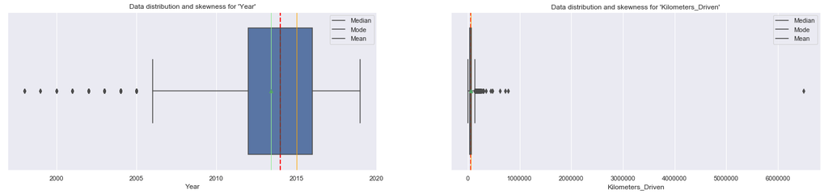

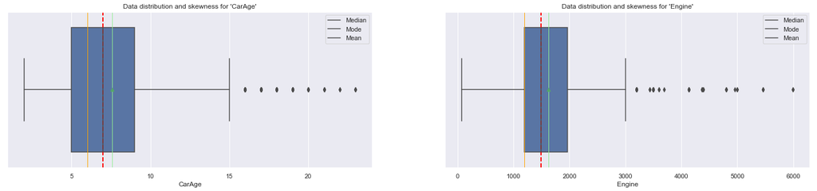

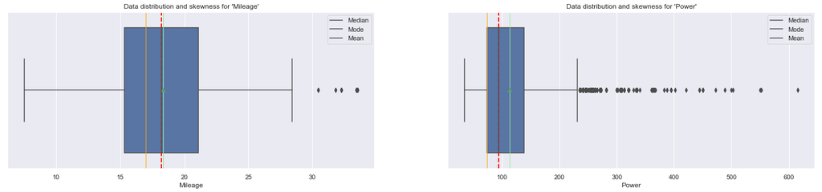

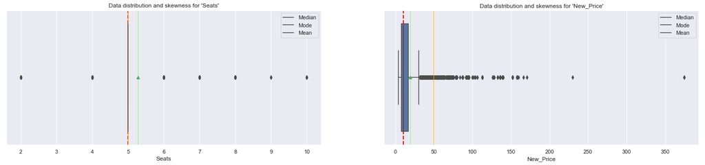

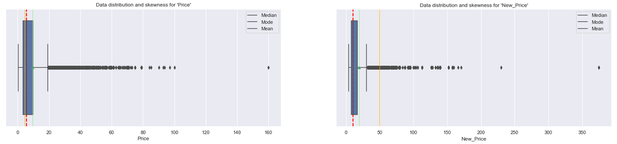

```python
columns= ["Year","Kilometers_Driven"]
drawTwoColumnBoxPlotGraph(columns,df)

columns= ["CarAge","Engine"]
drawTwoColumnBoxPlotGraph(columns,df)

columns= ["Mileage","Power"]
drawTwoColumnBoxPlotGraph(columns,df)

columns= ["Seats","New_Price"]
drawTwoColumnBoxPlotGraph(columns,df)

columns= ["Price","New_Price"]
drawTwoColumnBoxPlotGraph(columns,df)
```

**Observations**

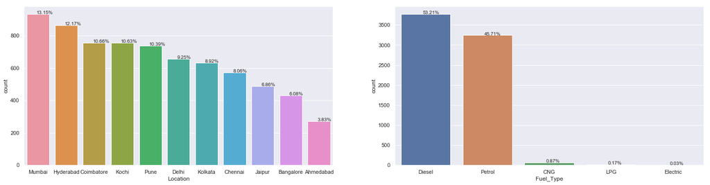

```python
fig, axes = plt.subplots(ncols=2,figsize=(25, 6))
drawCountPlot('Location',axes[0],df)
drawCountPlot('Fuel_Type',axes[1],df)
```

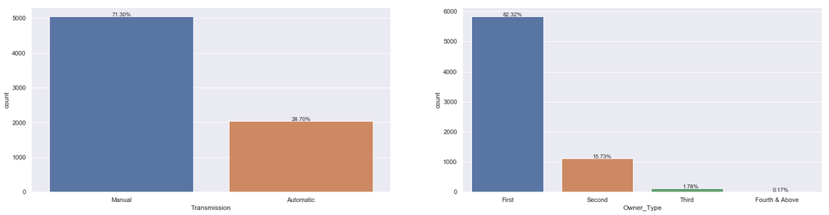

```python
fig, axes = plt.subplots(ncols=2,figsize=(25, 6))
drawCountPlot('Transmission',axes[0],df)
drawCountPlot('Owner_Type',axes[1],df)
```

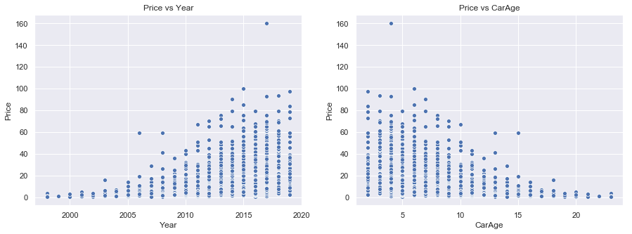

```python
fig, axes = plt.subplots(ncols=2,figsize=(15, 5))
drawScatterPlot('Year','Price',df,axes[0])
drawScatterPlot('CarAge','Price',df,axes[1]);
```

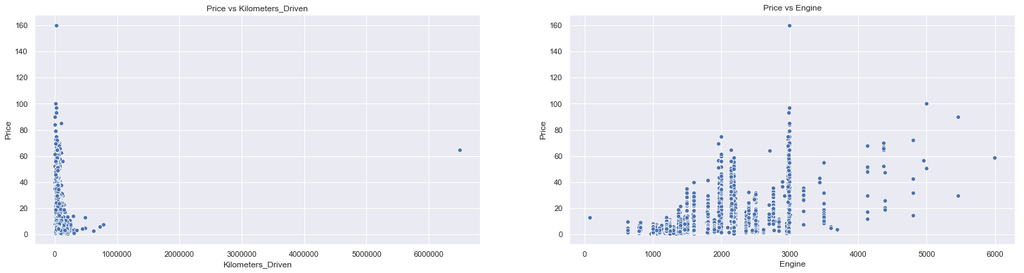

```python
fig, axes = plt.subplots(ncols=2,figsize=(25, 6))
drawScatterPlot('Kilometers_Driven','Price',df,axes[0])
drawScatterPlot('Engine','Price',df,axes[1]);
```

**As Kilometers_Driven is highly skewed data, data distribution is not very clear. Lets try using log transformation**

```
[Text(0.5,1,'log(Kilometers_Driven) vs log(Price)')]
```

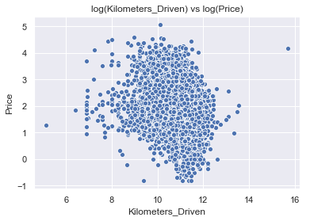

```python
sns.scatterplot(x=np.log(df['Kilometers_Driven']),y=np.log(df['Price'])).set(title='log(Kilometers_Driven) vs log(Price)')
```

**Observation**

- There is no major impact of Kilometers_Driven on price.
- There is a outlier a Price of 160 for log(Kilometers_Driven)=10

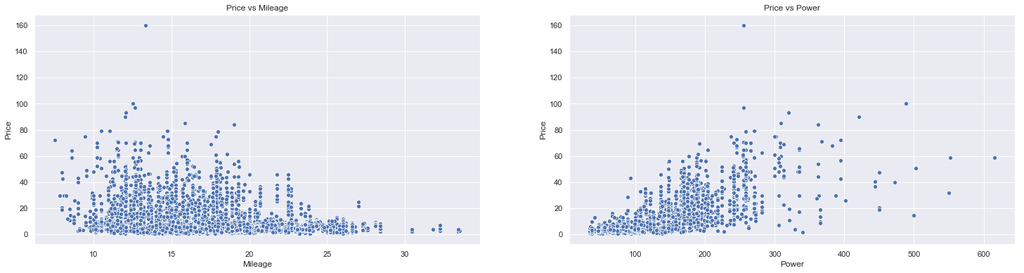

```python
fig, axes = plt.subplots(ncols=2,figsize=(25, 6))
drawScatterPlot('Mileage','Price',df,axes[0]);
drawScatterPlot('Power','Price',df,axes[1]);
```

**Observations**

- 82% cars are First hand used cars
- 53.21% cars is of type Disel
- 71% cars is manual transmission type
- Mumbai has the highest mnumbers of cars
- Price of the car decreases as the CarAge increasing
- Kilometers_Driven has outliers, needs cleanup

#### Bivariate & Multivariate Analysis

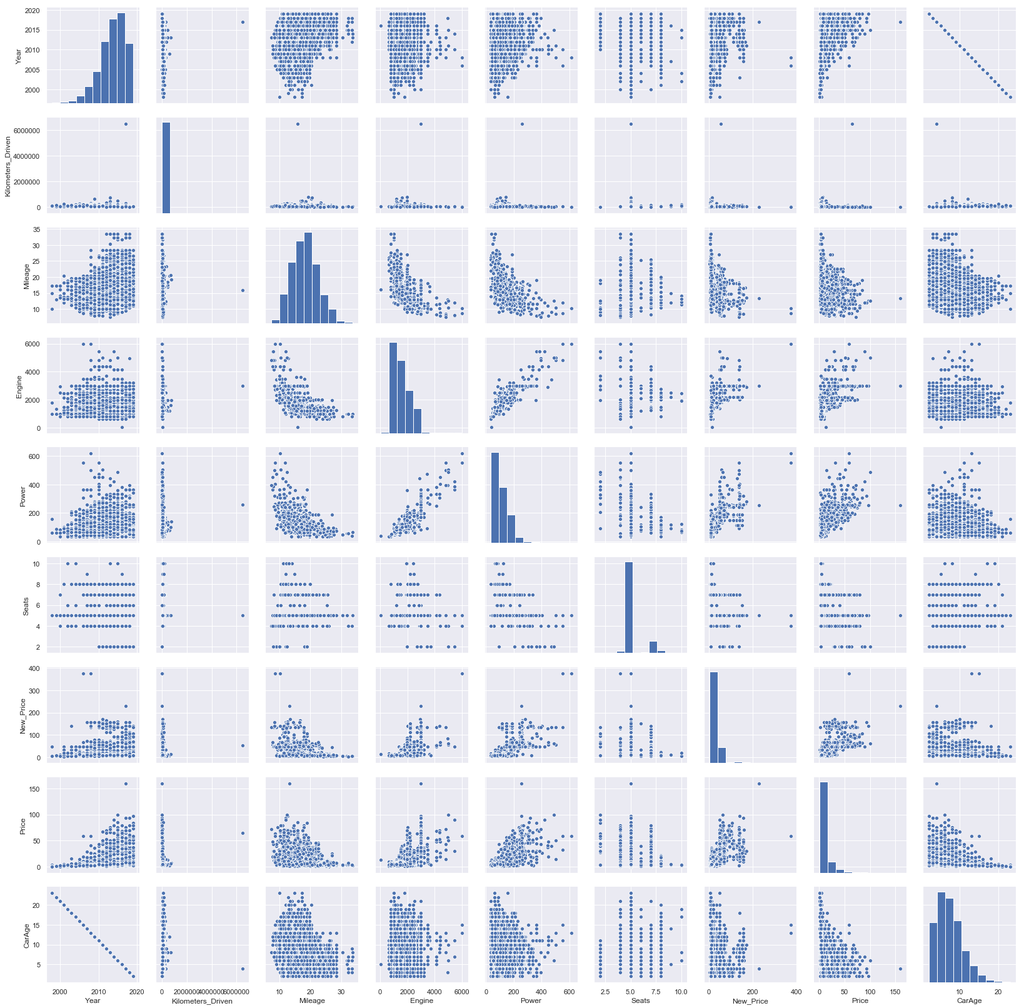

```python
sns.pairplot(data=df)
```

#### EDA of Price correlation with other columns

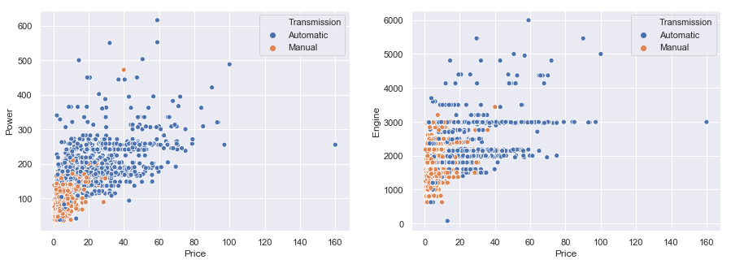

```python
fig, axes = plt.subplots(ncols=2,figsize=(15, 5))

# Price relation with Power and Transmission
sns.scatterplot(x='Price',y='Power', hue='Transmission', data=df,ax=axes[0]);

# Price relation with Engine and Transmission
sns.scatterplot(x='Price',y='Engine', hue='Transmission', data=df,ax=axes[1]);
```

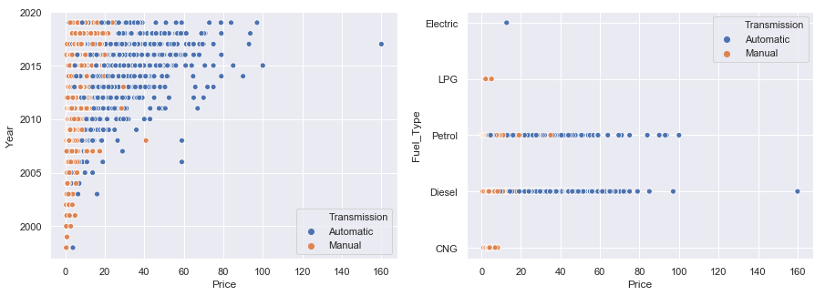

```python
fig, axes = plt.subplots(ncols=2,figsize=(15, 5))

# Price relation with Year and Transmission
sns.scatterplot(x='Price',y='Year', hue='Transmission', data=df,ax=axes[0]);

# Price relation with Fuel_Type and Transmission
sns.scatterplot(x='Price',y='Fuel_Type', hue='Transmission', data=df,ax=axes[1]);
```

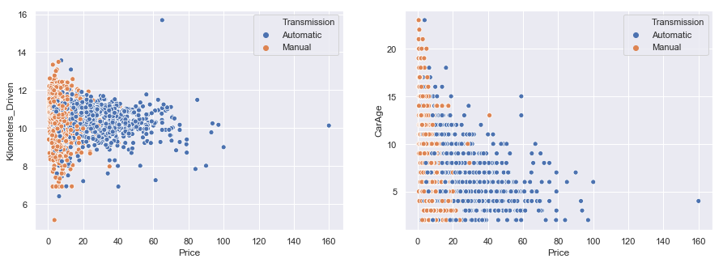

```python
fig, axes = plt.subplots(ncols=2,figsize=(15, 5))

# Price relation with log(Kilometers_Driven) and Transmission
sns.scatterplot(x='Price',y=np.log(df['Kilometers_Driven']), hue='Transmission', data=df,ax=axes[0]);

# Price relation with CarAge and Transmission
sns.scatterplot(x='Price',y='CarAge', hue='Transmission', data=df,ax=axes[1]);
```

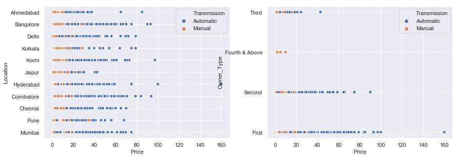

```python
fig, axes = plt.subplots(ncols=2,figsize=(15, 5))

# Price relation with Location and Transmission
sns.scatterplot(x='Price',y='Location', hue='Transmission', data=df,ax=axes[0]);

# Price relation with Owner_Type and Transmission
sns.scatterplot(x='Price',y='Owner_Type', hue='Transmission', data=df,ax=axes[1]);
```

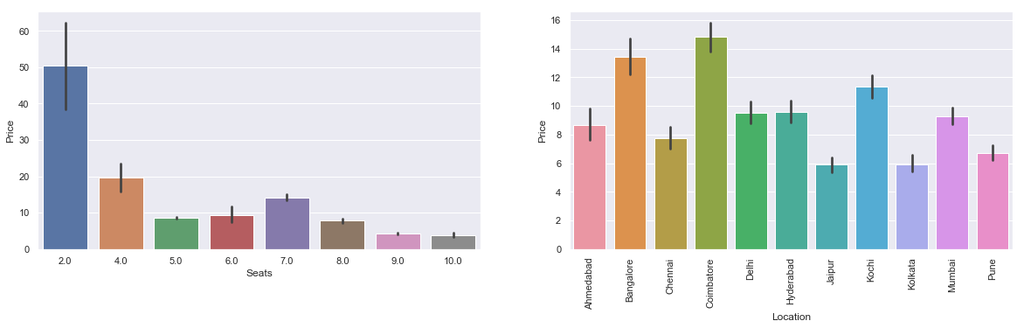

```python
fig, axes = plt.subplots(ncols=2,figsize=(20, 5))
plt.xticks(rotation=90)
sns.catplot(y='Price',x='Seats',kind="bar", data=df, ax=axes[0]);
sns.catplot(y='Price',x='Location',kind="bar", data=df,ax=axes[1]);
plt.close(2)
plt.close(3)
```

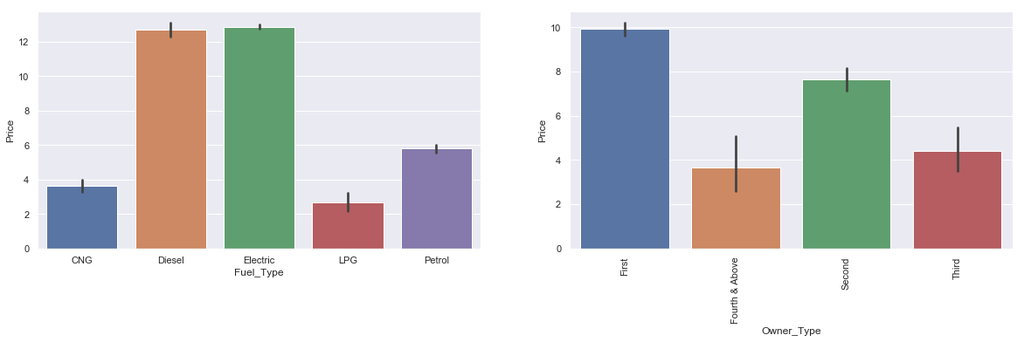

```python
fig, axes = plt.subplots(ncols=2,figsize=(20, 5))
plt.xticks(rotation=90)
sns.catplot(y='Price',x='Fuel_Type',kind="bar", data=df, ax=axes[0]);
sns.catplot(y='Price',x='Owner_Type',kind="bar", data=df,ax=axes[1]);
plt.close(2)
plt.close(3)
```

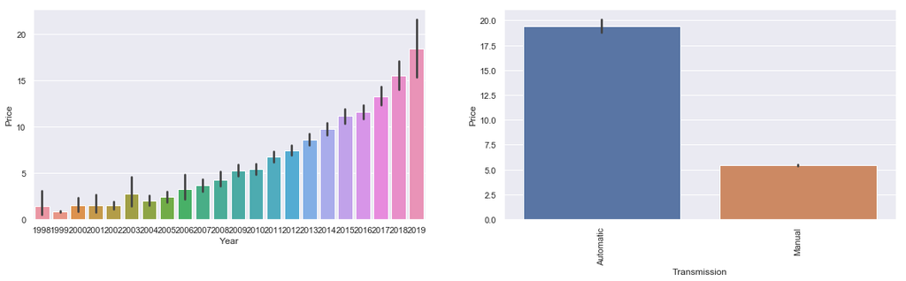

```python
fig, axes = plt.subplots(ncols=2,figsize=(20, 5))
plt.xticks(rotation=90)
sns.catplot(y='Price',x='Year',kind="bar", data=df, ax=axes[0]);
sns.catplot(y='Price',x='Transmission',kind="bar", data=df,ax=axes[1]);
plt.close(2)
plt.close(3)
```

**Observation**

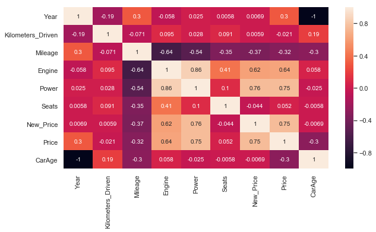

```python
plt.figure(figsize=(10,5))
sns.heatmap(df.corr(),annot=True)
```

**Observation**

- Power (0.86) very has high +ve correlation with Engine
- Engine has high +ve correlation (around 0.62) with Price, New_Price
- Power has high +ve correlation (around 0.75) with Price, New_Price
- Mileage has high -ve correction (above 0.54) with Power and Engine
- Car Price is -ve correlated with CarAge & Mileage
- Kilometers_Driven and Seats doesn't make difference in cars price

## Model Building

### Utility Methods

```python
# Adjusted R^2
def adj_r2(ind_vars, targets, predictions):
    r2 = r2_score(targets, predictions)
    n = ind_vars.shape[0]
    k = ind_vars.shape[1]
    return 1 - ((1 - r2) * (n - 1) / (n - k - 1))


# Model performance check
def model_perf(model, inp, out):

    y_pred = model.predict(inp)
    y_act = out.values

    return pd.DataFrame(
        {
            "RMSE": np.sqrt(mean_squared_error(y_act, y_pred)),
            "MAE": mean_absolute_error(y_act, y_pred),
            "R^2": r2_score(y_act, y_pred),
            "Adjusted R^2": adj_r2(inp, y_act, y_pred),
        },
        index=[0],
    )

# Encode catagorical vairables in a data frame using pd.get_dummies(...)
def encode_cat_vars(x):
    x = pd.get_dummies(
        x,
        columns=x.select_dtypes(include=["object", "category"]).columns.tolist(),
        drop_first=True,
    )
    return x


## Handles outlier values
def outlierHandling(df,columnName):
    Q1=df[columnName].quantile(0.25) # 25th quantile
    Q3=df[columnName].quantile(0.75)  # 75th quantile
    IQR=Q3-Q1
    lowerWhisker = Q1 - 1.5*IQR
    upperWhisker = Q3 + 1.5*IQR

    # Assign lowerWhisker value to all the values lower than it
    # Assign upperWhisker value to all the values larger than it
    df[columnName] = np.clip(df[columnName], lowerWhisker, upperWhisker)
    return df
```

### Model Building without Outlier Treatment

```python
# make a copy of dataset
df1=df.copy()
```

#### Define dependent variable

```python
# Create Dependent and Independent variables by drop not required columns
ind_vars = df1.drop(['Name','Price','Brand','Model'], axis=1)
dep_var = df1[['Price']]
```

```python
ind_vars.info()
```

```
<class 'pandas.core.frame.DataFrame'>
Int64Index: 7094 entries, 0 to 7252
Data columns (total 12 columns):
Location             7094 non-null category
Year                 7094 non-null int64
Kilometers_Driven    7094 non-null int64
Fuel_Type            7094 non-null category
Transmission         7094 non-null category
Owner_Type           7094 non-null category
Mileage              7094 non-null float64
Engine               7094 non-null float64
Power                7094 non-null float64
Seats                7094 non-null float64
New_Price            7094 non-null float64
CarAge               7094 non-null int64
dtypes: category(4), float64(5), int64(3)
memory usage: 527.4 KB
```

#### Creating dummy variables

```python
# enacode categorical variables to dummies of dataframe 'ind_vars'
ind_vars_num = encode_cat_vars(ind_vars)
ind_vars_num.head()
```

|  | Year | Kilometers_Driven | Mileage | Engine | Power | Seats | New_Price | CarAge | Location_Bangalore | Location_Chennai | Location_Coimbatore | Location_Delhi | Location_Hyderabad | Location_Jaipur | Location_Kochi | Location_Kolkata | Location_Mumbai | Location_Pune | Fuel_Type_Diesel | Fuel_Type_Electric | Fuel_Type_LPG | Fuel_Type_Petrol | Transmission_Manual | Owner_Type_Fourth & Above | Owner_Type_Second | Owner_Type_Third |
| --- | --- | --- | --- | --- | --- | --- | --- | --- | --- | --- | --- | --- | --- | --- | --- | --- | --- | --- | --- | --- | --- | --- | --- | --- | --- | --- |
| 0 | 2010 | 72000 | 26.60 | 998.0 | 58.16 | 5.0 | 5.325 | 11 | 0 | 0 | 0 | 0 | 0 | 0 | 0 | 0 | 1 | 0 | 0 | 0 | 0 | 0 | 1 | 0 | 0 | 0 |
| 1 | 2015 | 41000 | 19.67 | 1582.0 | 126.20 | 5.0 | 18.320 | 6 | 0 | 0 | 0 | 0 | 0 | 0 | 0 | 0 | 0 | 1 | 1 | 0 | 0 | 0 | 1 | 0 | 0 | 0 |
| 2 | 2011 | 46000 | 18.20 | 1199.0 | 88.70 | 5.0 | 8.610 | 10 | 0 | 1 | 0 | 0 | 0 | 0 | 0 | 0 | 0 | 0 | 0 | 0 | 0 | 1 | 1 | 0 | 0 | 0 |
| 3 | 2012 | 87000 | 20.77 | 1248.0 | 88.76 | 7.0 | 10.990 | 9 | 0 | 1 | 0 | 0 | 0 | 0 | 0 | 0 | 0 | 0 | 1 | 0 | 0 | 0 | 1 | 0 | 0 | 0 |
| 4 | 2013 | 40670 | 15.20 | 1968.0 | 140.80 | 5.0 | 53.140 | 8 | 0 | 0 | 1 | 0 | 0 | 0 | 0 | 0 | 0 | 0 | 1 | 0 | 0 | 0 | 0 | 0 | 1 | 0 |

```python
# Check the shape of the ind_vars_num
ind_vars_num.shape
```

```
(7094, 26)
```

```python
# Information about the dataframe 'ind_vars_num'
ind_vars_num.info()
```

```
<class 'pandas.core.frame.DataFrame'>
Int64Index: 7094 entries, 0 to 7252
Data columns (total 26 columns):
Year                         7094 non-null int64
Kilometers_Driven            7094 non-null int64
Mileage                      7094 non-null float64
Engine                       7094 non-null float64
Power                        7094 non-null float64
Seats                        7094 non-null float64
New_Price                    7094 non-null float64
CarAge                       7094 non-null int64
Location_Bangalore           7094 non-null uint8
Location_Chennai             7094 non-null uint8
Location_Coimbatore          7094 non-null uint8
Location_Delhi               7094 non-null uint8
Location_Hyderabad           7094 non-null uint8
Location_Jaipur              7094 non-null uint8
Location_Kochi               7094 non-null uint8
Location_Kolkata             7094 non-null uint8
Location_Mumbai              7094 non-null uint8
Location_Pune                7094 non-null uint8
Fuel_Type_Diesel             7094 non-null uint8
Fuel_Type_Electric           7094 non-null uint8
Fuel_Type_LPG                7094 non-null uint8
Fuel_Type_Petrol             7094 non-null uint8
Transmission_Manual          7094 non-null uint8
Owner_Type_Fourth & Above    7094 non-null uint8
Owner_Type_Second            7094 non-null uint8
Owner_Type_Third             7094 non-null uint8
dtypes: float64(5), int64(3), uint8(18)
memory usage: 623.5 KB
```

#### Split the data into train and test

```python
x_train, x_test, y_train, y_test = train_test_split(
    ind_vars_num, dep_var, test_size=0.3, random_state=1
)
```

```python
print("Number of rows in train data =", x_train.shape[0])
print("Number of rows in test data =", x_test.shape[0])
```

```
('Number of rows in train data =', 4965)
('Number of rows in test data =', 2129)
```

#### Fitting a linear model

```python
lin_reg_model = LinearRegression()
lin_reg_model.fit(x_train, y_train)
```

```
LinearRegression(copy_X=True, fit_intercept=True, n_jobs=None,
         normalize=False)
```

```python
coef_df = pd.DataFrame(
    np.append(lin_reg_model.coef_.flatten(), lin_reg_model.intercept_),
    index=x_train.columns.tolist() + ["Intercept"],
    columns=["Coefficients"],
)
coef_df
```

|  | Coefficients |
| --- | --- |
| Year | 0.484764 |
| Kilometers_Driven | 0.000002 |
| Mileage | -0.147308 |
| Engine | 0.001045 |
| Power | 0.061669 |
| Seats | -0.318986 |
| New_Price | 0.192685 |
| CarAge | -0.484764 |
| Location_Bangalore | 1.592501 |
| Location_Chennai | 0.459381 |
| Location_Coimbatore | 1.422844 |
| Location_Delhi | -0.488107 |
| Location_Hyderabad | 0.439739 |
| Location_Jaipur | 0.248553 |
| Location_Kochi | -0.012042 |
| Location_Kolkata | -0.904383 |
| Location_Mumbai | -1.208021 |
| Location_Pune | -0.274923 |
| Fuel_Type_Diesel | -0.722329 |
| Fuel_Type_Electric | 5.809694 |
| Fuel_Type_LPG | 1.300013 |
| Fuel_Type_Petrol | -1.955599 |
| Transmission_Manual | -1.486180 |
| Owner_Type_Fourth & Above | 3.660151 |
| Owner_Type_Second | -0.787100 |
| Owner_Type_Third | 0.118944 |
| Intercept | -968.593160 |

#### Model performance check

- We will be using metric functions defined in sklearn for RMSE, MAE, and $R^2$.
- We will define a function to calculate adjusted $R^2$.
- We will create a function that will print out all the above metrics in one go.

```python
# Checking model performance on train set
print("Training Performance\n")
print(model_perf(lin_reg_model, x_train, y_train))

# Checking model performance on test set
print("\n\nTest Performance\n")
print(model_perf(lin_reg_model, x_test, y_test))
```

```
Training Performance

   Adjusted R^2       MAE    RMSE       R^2
0      0.745639  3.139788  5.4525  0.746971


Test Performance

   Adjusted R^2      MAE      RMSE       R^2
0        0.7246  3.14392  5.709993  0.727965
```

**Observations**

- The train and test $R^2$ are 0.745 and 0.724, indicating that the model explains 74.5% and 72.4% of the total variation in the train and test sets respectively. Also, both scores are comparable.
- RMSE values on the train and test sets are also comparable.
- This shows that the model is not overfitting.
- MAE indicates that our current model is able to predict price within a mean error of 3.14392 on the test set.

### Model Building with Outlier Treatment

```python
# make a copy of dataset
df3=df.copy()
```

```python
# Perform the treatment of outliers for all numeric columns
columns = df3.select_dtypes(include=np.number).columns.tolist()
for column in columns:
    df3 = outlierHandling(df3,column)
```

#### Define dependent variable

```python
# Create Dependent and Independent variables by drop not required columns
ind_vars = df3.drop(['Name','Price','Brand','Model'], axis=1)
dep_var = df3[['Price']]
```

#### Creating dummy variables

```python
# enacode categorical variables to dummies of dataframe 'ind_vars'
ind_vars_num = encode_cat_vars(ind_vars)
ind_vars_num.head()
```

|  | Year | Kilometers_Driven | Mileage | Engine | Power | Seats | New_Price | CarAge | Location_Bangalore | Location_Chennai | Location_Coimbatore | Location_Delhi | Location_Hyderabad | Location_Jaipur | Location_Kochi | Location_Kolkata | Location_Mumbai | Location_Pune | Fuel_Type_Diesel | Fuel_Type_Electric | Fuel_Type_LPG | Fuel_Type_Petrol | Transmission_Manual | Owner_Type_Fourth & Above | Owner_Type_Second | Owner_Type_Third |
| --- | --- | --- | --- | --- | --- | --- | --- | --- | --- | --- | --- | --- | --- | --- | --- | --- | --- | --- | --- | --- | --- | --- | --- | --- | --- | --- |
| 0 | 2010 | 72000.0 | 26.60 | 998.0 | 58.16 | 5.0 | 5.325 | 11 | 0 | 0 | 0 | 0 | 0 | 0 | 0 | 0 | 1 | 0 | 0 | 0 | 0 | 0 | 1 | 0 | 0 | 0 |
| 1 | 2015 | 41000.0 | 19.67 | 1582.0 | 126.20 | 5.0 | 18.320 | 6 | 0 | 0 | 0 | 0 | 0 | 0 | 0 | 0 | 0 | 1 | 1 | 0 | 0 | 0 | 1 | 0 | 0 | 0 |
| 2 | 2011 | 46000.0 | 18.20 | 1199.0 | 88.70 | 5.0 | 8.610 | 10 | 0 | 1 | 0 | 0 | 0 | 0 | 0 | 0 | 0 | 0 | 0 | 0 | 0 | 1 | 1 | 0 | 0 | 0 |
| 3 | 2012 | 87000.0 | 20.77 | 1248.0 | 88.76 | 5.0 | 10.990 | 9 | 0 | 1 | 0 | 0 | 0 | 0 | 0 | 0 | 0 | 0 | 1 | 0 | 0 | 0 | 1 | 0 | 0 | 0 |
| 4 | 2013 | 40670.0 | 15.20 | 1968.0 | 140.80 | 5.0 | 30.840 | 8 | 0 | 0 | 1 | 0 | 0 | 0 | 0 | 0 | 0 | 0 | 1 | 0 | 0 | 0 | 0 | 0 | 1 | 0 |

#### Split the data into train and test

```python
from sklearn.model_selection import train_test_split
x_train, x_test, y_train, y_test = train_test_split(
    ind_vars_num, dep_var, test_size=0.3, random_state=1
)
```

```python
print("Number of rows in train data =", x_train.shape[0])
print("Number of rows in test data =", x_test.shape[0])
```

```
('Number of rows in train data =', 4965)
('Number of rows in test data =', 2129)
```

#### Fitting a linear model

```python
lin_reg_model = LinearRegression()
lin_reg_model.fit(x_train, y_train)
```

```
LinearRegression(copy_X=True, fit_intercept=True, n_jobs=None,
         normalize=False)
```

```python
coef_df = pd.DataFrame(
    np.append(lin_reg_model.coef_.flatten(), lin_reg_model.intercept_),
    index=x_train.columns.tolist() + ["Intercept"],
    columns=["Coefficients"],
)
coef_df
```

|  | Coefficients |
| --- | --- |
| Year | 2.679021e-01 |
| Kilometers_Driven | -1.506944e-05 |
| Mileage | -8.792353e-02 |
| Engine | 4.004331e-04 |
| Power | 3.484788e-02 |
| Seats | 7.271961e-15 |
| New_Price | 2.819971e-01 |
| CarAge | -2.679021e-01 |
| Location_Bangalore | 4.271452e-01 |
| Location_Chennai | 1.046859e-01 |
| Location_Coimbatore | 4.774276e-01 |
| Location_Delhi | -1.721571e-01 |
| Location_Hyderabad | 4.115127e-01 |
| Location_Jaipur | 4.103221e-01 |
| Location_Kochi | 1.611016e-01 |
| Location_Kolkata | -8.915291e-01 |
| Location_Mumbai | -4.538769e-01 |
| Location_Pune | -9.806822e-02 |
| Fuel_Type_Diesel | 2.120726e-01 |
| Fuel_Type_Electric | 4.837095e+00 |
| Fuel_Type_LPG | 2.762196e-01 |
| Fuel_Type_Petrol | -1.019624e+00 |
| Transmission_Manual | -9.396427e-01 |
| Owner_Type_Fourth & Above | 8.563187e-01 |
| Owner_Type_Second | -3.773713e-01 |
| Owner_Type_Third | -2.424533e-01 |
| Intercept | -5.346487e+02 |

#### Coefficient interpretations

- Coefficients of Year, Engine, Power, seats, New_Price, Some location like (Banglore, Chennai,oimbatore) ), Fuel_Type (like Diesel, Electric), Owner_Type_Fourth & Above are positives, that is increase in these will lead to increase in price
- Coefficients of Mileage, Kilometers_Driven, CarAge, Transmission_Manual, Owner_Type_Second and Owner_Type_Third, Fuel_Type (like Petrol) and Locations like Pune, Kolkata are negatives, that is increase in these will lead to decrease of price

#### Model performance check

- We will be using metric functions defined in sklearn for RMSE, MAE, and $R^2$.
- We will define a function to calculate adjusted $R^2$.
- We will create a function that will print out all the above metrics in one go.

```python
# Checking model performance on train set
print("Training Performance\n")
print(model_perf(lin_reg_model, x_train, y_train))

# Checking model performance on test set
print("\n\nTest Performance\n")
print(model_perf(lin_reg_model, x_test, y_test))
```

```
Training Performance

   Adjusted R^2       MAE      RMSE       R^2
0      0.863089  1.526519  2.089808  0.863806


Test Performance

   Adjusted R^2       MAE     RMSE       R^2
0      0.860185  1.520666  2.09818  0.861894
```

**Observations**

- The train and test $R^2$ are 0.863 and 0.860, indicating that the model explains 86.3% and 86.1% of the total variation in the train and test sets respectively. Also, both scores are comparable.
- RMSE values on the train and test sets are also comparable.
- This shows that the model is not overfitting.
- MAE indicates that our current model is able to predict price within a mean error of 1.520666 lakh on the test set.